# Thermal performance: CFUs and growth curves time-to-detection analyses

1st & 2nd authors

# Introduction

This notebook is for analyzing the temperature growth curves data produced by 1st & 2nd authors, as well as the survival CFU data produced by 1st author. It summarizes the findings for publication. This notebook was created by copying the relevant sections from `XXX.Rmd` and `plate_reader_calibration.Rmd`.

The goal is to describe the thermal niche of different *Pseudomonas* strains present in the XXX lab of XXX (XXX). The main question the experiments are trying to answer: Is there a relationship between a strain’s growth (fast VS slow grower) and its thermal niche?

See the associated manuscript for more details. This notebook covers all analyses performed for Experiment I in the manuscript.

## The data

16 soil *Pseudomonas* strains were used in total (BSC001 - BSC010, BSC015, BSC019, CK101 - CK104), inoculated either from early exponential phase or from stationary phase.

There are 3 data sets which are integrated in this analysis:

1. Colony forming unit (CFU) data for all 16 strains growing at 28C, 35C, and 40C.
2. Growth curves inoculated in a 10-fold serial dilution at 6 different starting concentrations ($N_0$) and 4 different temperatures (25C, 30C, 35C, and 40C). The CFU data is integrated into this analysis because it is used to infer the OD-converted inoculum size for each strain x temperature combination.
3. Dilution series performed on both of the microspectrophotometers in our lab. This is used to integrate the CFU data with the OD data (see above).

All data files and protocols are associated with the above analyses are available in the folder and sub-folders where this file is found.

```r
# load environment
library(tidyverse)
library(readxl) # for importing data directly from Excel sheet
library(broom) # for easy fitting of several lm's from the same df
library(Hmisc) # for calculating non-parametric bootstrap confidence intervals
```

```r
library(AICcmodavg) # AIC comparison for survival CFU data
library(gcplyr) # for smooth plotting of growth curve data & for plotting intraspecific density dependence of growth rate
library(CarletonStats) # for bootstrapping the slope of linear regression
library(DescTools) # for Kendall's Coefficient of Concordance (Wt)
library(glmmTMB) # for linear mixed effects model
library(emmeans) # for summarizing effects of LMM models
library(rcompanion) # for r-squared estimates of LMM models

# this is a set of custom functions written by AHG:
source("H1_extract_data_fun_v3-1.R") # for getting the data into R from the default H1 txt export format

# print the complete info about packages and versions currently loaded in the environment:
```

```r
# set theme for all plots
fave_theme <- theme_light() + # see other options at https://ggplot2.tidyverse.org/reference/ggtheme.html
  theme(text = element_text(size=15), # larger text size for titles & axes
        panel.grid.major = element_blank(), # remove major gridlines
        panel.grid.minor = element_blank()) # remove minor gridlines
theme_set(fave_theme)

# define a palette for plotting all 6 species
ALLsp_palette = palette.colors(8, palette = "R4")[2:7]
```

# Plate reader calibration for CFU-to-OD conversion

Analysis of data generated by following the protocol `OD Calibration to CFUs.docx`.

Fairly exhaustive calibrations were done for the microplate spectrophotometers (hereafter referred to generally as “plate readers” or specifically by the name of each instrument, BioTek Synergy H1 or Biotek Epoch2). Different *Pseudomonas* species were grown in different culture conditions (96-well microplate, tube, or Erlenmeyer), temperatures (25C or 40C), and culture phases (exponential or stationary). Then, dilution series were made. These were measured by spectrophotometer at 600nm (OD$_{600}$) and by CFU to get the calibration. There were a lot of inconsistencies; these are to be expected since OD measures the amount of scattered light, which depends in part on cell density but also on cell size, clumping, etc.

Anyway, I tried my best to estimate a calibration curve.

## Load & parse data

```r
#####################################
# load the microplate OD data
#####################################
synergy.df <- read_excel("./data/calibration_spectrophotometers--22Feb24.xlsx", sheet="microplate H1") %>%
                pivot_longer(cols=`25_rep1`:`40_rep6`,
                                   names_to=c("Temp", "Rep"),
                                   names_pattern="(.*)_rep(.)",
                                   values_to="OD") # reorganize the shape of the dataframe
epoch.df <- read_excel("./data/calibration_spectrophotometers--22Feb24.xlsx", sheet="microplate Epoch") %>%
                pivot_longer(cols=`25_rep1`:`40_rep6`,
                                   names_to=c("Temp", "Rep"),
                                   names_pattern="(.*)_rep(.)",
                                   values_to="OD") # reorganize the shape of the dataframe

# load the microplate CFU data
plateCFU.df <- read_excel("./data/calibration_spectrophotometers--22Feb24.xlsx", sheet="microplate_CFU")

#####################################
# baseline subtract using the blanks as well as the bottom 3 lowest dilutions for each sample
#####################################

## check if there's any systematic trend in the baseline value
#baseline_trend <- rbind(synergy.df %>% add_column(machine="Synergy"), # combine the data from the 2 plate readers
#                        epoch.df %>% add_column(machine="Epoch")) %>%
#                    filter(Dilution < 5e-06) %>%                      # keep blanks & 3 lowest dilutions
#                      # get median value for each temperature & replicate
#                      select(-Dilution, -Sample) %>% group_by(Temp, Rep, machine) %>%
#                          summarise(medianBlankOD = median(OD, na.rm=TRUE),
#                                    ICR_lo = quantile(OD, probs=0.25),
#                                    ICR_hi = quantile(OD, probs=0.75))
#ggplot(baseline_trend, aes(x=Rep, y=medianBlankOD, colour=Temp)) +
#  facet_wrap(vars(machine), scales="free") +
#  geom_errorbar(aes(ymin=ICR_lo, ymax=ICR_hi), width=0.2) +
#  geom_point()
## there is NO systematic trend in the baseline value
#rm(baseline_trend)

# in this case it seems there's a difference in the baselines for different incubation temperatures, but only for the Epoch2...

# baseline everything in the same way as before
synergy.df <- inner_join(synergy.df %>% filter(Dilution < 5e-06) %>%
                            select(-Dilution, -Sample) %>% # get the blanks & calculate mean value for each Temp & Rep
                                group_by(Temp, Rep) %>% summarise(medianBlankOD = median(OD, na.rm=TRUE)),
                          synergy.df %>% filter(Dilution > 5e-06) # add the medianBlankOD back to the data without the samples used for blanking
                        ) %>% mutate(baselinedOD = OD-medianBlankOD)
epoch.df <- inner_join(epoch.df %>% filter(Dilution < 5e-06) %>%
                          select(-Dilution, -Sample) %>% # get the blanks & calculate mean value for each Temp & Rep
                              group_by(Temp, Rep) %>%
                                summarise(medianBlankOD = median(OD, na.rm=TRUE)),
                       epoch.df %>% filter(Dilution > 5e-06) # add the medianBlankOD back to the data without the samples used for blanking
                      ) %>% mutate(baselinedOD = OD-medianBlankOD)
#####################################
# estimate the mean CFU of each sample
#####################################
plateCFU.df <- plateCFU.df %>% mutate(CFU_per_mL = `CFU per 100uL`/Dilution*10) %>%
                group_by(Sample, Phase, Incubation) %>%
                  summarise(meanCFU = mean(CFU_per_mL),
                            sdCFU = sd(CFU_per_mL))
# combine the CFU data with the OD data & infer the CFU for each dilution used in the OD data
synergy.df <- left_join(synergy.df, plateCFU.df) %>%
                mutate(inferred_meanDensity = meanCFU*Dilution,
                       inferred_sdDensity = sdCFU*Dilution) %>%
                  select(-meanCFU, -sdCFU)
epoch.df <- left_join(epoch.df, plateCFU.df) %>%
                mutate(inferred_meanDensity = meanCFU*Dilution,
                       inferred_sdDensity = sdCFU*Dilution) %>%
                  select(-meanCFU, -sdCFU)
# remove some of the data points because it seems we are hitting up against the limit of detection
synergy.df <- synergy.df %>% filter(inferred_meanDensity > 5e+04,
                                    baselinedOD > 5e-03,
                                    Temp==25) # drop the 40C because it looks even worse than 25C
# remove some of the data points because it seems we are hitting up against the limit of detection
epoch.df <- epoch.df %>% filter(inferred_meanDensity > 1e+04,
                           baselinedOD > 5e-03,
                           Temp==25) # again remove OD acquisition temp of 40C

# create columns for log10 values
synergy.df <- synergy.df %>%
                mutate(log10_OD = log10(baselinedOD),
                       log10_density = log10(inferred_meanDensity)) %>%
                 filter(log10_OD > -Inf)
epoch.df <- epoch.df %>%
              mutate(log10_OD = log10(baselinedOD),
                     log10_density = log10(inferred_meanDensity)) %>%
                 filter(log10_OD > -Inf)

# store the raw data
all_calib.data <- rbind(synergy.df %>% mutate(Detector="synergy"),
                        epoch.df %>% mutate(Detector="epoch")) %>% ungroup() %>%
                    select(-Rep, -medianBlankOD, -Dilution, -OD, -Temp) %>%
                      separate_wider_delim(Incubation, "C ", names=c("Incubation_temp", "Flask")) %>%
                        mutate(OD_temp=25)
all_calib.data$Incubation_temp <- as.numeric(all_calib.data$Incubation_temp)

rm(epoch.df, synergy.df, plateCFU.df)
```

Load additional data…

```r
# load the microplate OD data
synergy.df <- read_excel("./data/calibration_spectrophotometers--26Feb24.xlsx", sheet="microplate H1") %>%
                pivot_longer(cols =`rep1`:`rep6`,
                             names_to = "Rep",
                             names_pattern="rep(.)",
                             values_to="OD") %>% # reorganize the shape of the dataframe
                  mutate(OD_temp = 25)
epoch.df <- read_excel("./data/calibration_spectrophotometers--26Feb24.xlsx", sheet="microplate Epoch") %>%
              pivot_longer(cols =`rep1`:`rep6`,
                             names_to = "Rep",
                             names_pattern="rep(.)",
                             values_to="OD") %>% # reorganize the shape of the dataframe
                  mutate(OD_temp = 40)

# load the microplate CFU data
plateCFU.df <- read_excel("./data/calibration_spectrophotometers--26Feb24.xlsx", sheet="microplate_CFU")

# baseline subtract using the blanks as well as the bottom 1 lowest dilution for each sample

## check if there's any systematic trend in the baseline value
#baseline_trend <- rbind(synergy.df %>% add_column(machine="Synergy"), # combine the data from the 2 plate readers
#                        epoch.df %>% add_column(machine="Epoch")) %>%
#                    filter(Dilution < 1e-06) %>%                      # keep blanks & 3 lowest dilutions
#                      # get median value for each reader & replicate
#                      select(-Dilution, -Sample) %>% group_by(Rep, machine, Incubation) %>%
#                          summarise(medianBlankOD = median(OD, na.rm=TRUE),
#                                    ICR_lo = quantile(OD, probs=0.25, na.rm=TRUE),
#                                    ICR_hi = quantile(OD, probs=0.75, na.rm=TRUE))
#ggplot(baseline_trend, aes(x=Rep, y=medianBlankOD, colour=Incubation)) +
#  facet_wrap(vars(machine), scales="free") +
#  geom_errorbar(aes(ymin=ICR_lo, ymax=ICR_hi), width=0.2) +
#  geom_point()
## yes, there is a trend. But only for the Epoch2 plate reader and 25C data...
#rm(baseline_trend)

# remove the first 5 replicates in the "25C plate" Epoch data
epoch.df <- rbind(epoch.df %>% filter(Incubation == "25C plate reader", Rep==6),
                  epoch.df %>% filter(Incubation == "40C plate reader", Rep<6))
# & remove the 6th replicate in the "40C plate" Epoch data (that one is all NA's anyway)


# now, after excluding problematic values, baseline similarly to previous data:
synergy.df <- inner_join(synergy.df %>% filter(Dilution < 1e-06) %>%
                            select(-Dilution, -Sample) %>% # get the blanks & calculate mean value for each Temp & Rep
                                group_by(Rep, Incubation) %>% summarise(medianBlankOD = median(OD, na.rm=TRUE)),
                          synergy.df %>% filter(Dilution > 1e-06) # add the medianBlankOD back to the data without the samples used for blanking
                        ) %>% mutate(baselinedOD = OD-medianBlankOD)
```

[output not shown]

```r
epoch.df <- inner_join(epoch.df %>% filter(Dilution < 1e-06) %>%
                          select(-Dilution, -Sample) %>% # get the blanks & calculate mean value for each Temp & Rep
                              group_by(Rep, Incubation) %>% summarise(medianBlankOD = median(OD, na.rm=TRUE)),
                       epoch.df %>% filter(Dilution > 1e-06) # add the medianBlankOD back to the data without the samples used for blanking
                      ) %>% mutate(baselinedOD = OD-medianBlankOD)
```

[output not shown]

```r
# estimate the mean CFU of each sample
plateCFU.df <- plateCFU.df %>% mutate(CFU_per_mL = `CFU per 100uL`/Dilution*10) %>%
                group_by(Sample, Phase, Incubation) %>%
                  summarise(meanCFU = mean(CFU_per_mL),
                            sdCFU = sd(CFU_per_mL))
# combine the CFU data with the OD data & infer the CFU for each dilution used in the OD data
synergy.df <- left_join(synergy.df, plateCFU.df) %>%
                mutate(inferred_meanDensity = meanCFU*Dilution,
                       inferred_sdDensity = sdCFU*Dilution) %>%
                  select(-meanCFU, -sdCFU)
epoch.df <- left_join(epoch.df, plateCFU.df) %>%
                mutate(inferred_meanDensity = meanCFU*Dilution,
                       inferred_sdDensity = sdCFU*Dilution) %>%
                  select(-meanCFU, -sdCFU)
# remove some of the data points because it seems we are hitting up against the limit of detection
synergy.df <- rbind(synergy.df %>% filter(Sample=="BSC004", baselinedOD > 1e-02),
                    synergy.df %>% filter(Sample=="BSC008", Incubation=="25C plate reader", baselinedOD > 2e-02),
                    synergy.df %>% filter(Sample=="BSC008", Incubation=="40C plate reader", baselinedOD > 5e-02),
                    synergy.df %>% filter(Sample=="BSC015", Incubation=="25C plate reader", baselinedOD > 2e-02),
                    synergy.df %>% filter(Sample=="BSC015", Incubation=="40C plate reader", baselinedOD > 1e-02),
                    synergy.df %>% filter(Sample=="CK101", baselinedOD > 2e-02))
# remove the most concentrated samples because of violation of the Beer-Lambert law
synergy.df <- synergy.df %>% filter(baselinedOD < 1.4)

# remove some of the data points because it seems we are hitting up against the limit of detection
epoch.df <- rbind(epoch.df %>% filter(Sample %in% c("BSC004", "BSC008"), Incubation=="25C plate reader", baselinedOD > 5e-03),
                  epoch.df %>% filter(Sample %in% c("BSC015", "CK101"), Incubation=="25C plate reader", baselinedOD > 1e-02),
                  epoch.df %>% filter(Sample=="BSC015", Incubation=="40C plate reader", baselinedOD > 1e-02),
                  epoch.df %>% filter(Sample=="BSC008", Incubation=="40C plate reader", baselinedOD > 2e-02))
# remove the most concentrated samples because of violation of the Beer-Lambert law
epoch.df <- epoch.df %>% filter(baselinedOD < 1.1)


# get the log10 of the data
synergy.df <- synergy.df %>%
                mutate(log10_OD = log10(baselinedOD),
                       log10_density = log10(inferred_meanDensity)) %>%
                 filter(log10_OD > -Inf,
                        baselinedOD > 1e-13)

epoch.df <- epoch.df %>%
              mutate(log10_OD = log10(baselinedOD),
                     log10_density = log10(inferred_meanDensity)) %>%
                 filter(log10_OD > -Inf)

# store the raw data
temp.data <- rbind(synergy.df %>% mutate(Detector="synergy", OD_temp=25),
                   epoch.df %>% mutate(Detector="epoch", OD_temp=40)) %>% ungroup() %>%
               select(-Rep, -medianBlankOD, -Dilution, -OD) %>%
                 separate_wider_delim(Incubation, "C ", names=c("Incubation_temp", "Flask"))
temp.data$Incubation_temp <- as.numeric(temp.data$Incubation_temp)
all_calib.data <- rbind(all_calib.data %>% mutate(Sample = "BSC015"),
                        temp.data)

rm(epoch.df, synergy.df, plateCFU.df, temp.data)
```

## Estimate CFU to OD conversion

Let’s consider only bacteria grown in the microplate because this is most relevant to our experiments. Then, we’re interested in averaging across the effects of temperature, species, and microplate reader. So let’s simply use data from different temperatures, species, and readers to run a linear model where CFU is the independent variable and OD is the dependent.

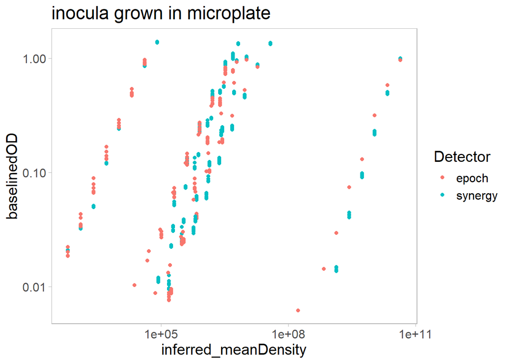

```r
ggplot(all_calib.data %>% filter(Flask == "plate reader"),
       aes(x=inferred_meanDensity, y=baselinedOD, colour=Detector)) +
  geom_point() +
  scale_y_log10() +
  scale_x_log10() +
  labs(title = "inocula grown in microplate")
```

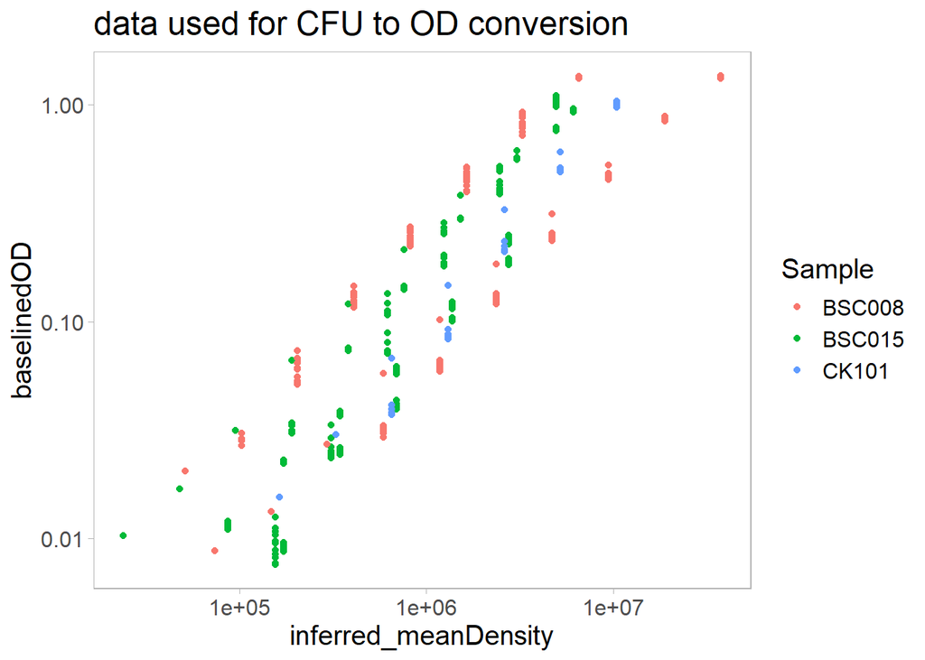

```r
## rather arbitrarily pick a subset of the data for creating the conversion
conversion.data <- all_calib.data %>% filter(Flask == "plate reader") %>%
                      filter(Sample != "BSC004") # exclude right side outlier
# exclude left side outlier
conversion.data <- conversion.data[-which(conversion.data$Sample=="BSC015" & conversion.data$Incubation_temp==40 & conversion.data$Phase=="Stationary"),]

# plot the final data that will be used for the conversion estimate:
ggplot(conversion.data, # here in terms of species
       aes(x=inferred_meanDensity, y=baselinedOD, colour=Sample)) +
  geom_point() +
  scale_y_log10() +
  scale_x_log10() +
  labs(title = "data used for CFU to OD conversion")
```

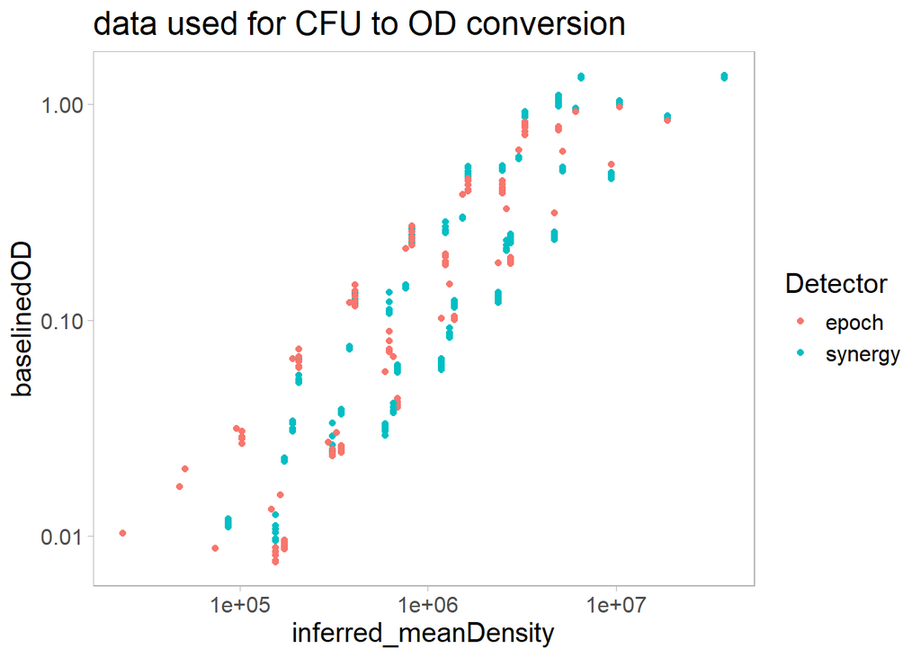

```r
# plot again in terms of the microplate reader
ggplot(conversion.data,
       aes(x=inferred_meanDensity, y=baselinedOD, colour=Detector)) +
  geom_point() +
  scale_y_log10() +
  scale_x_log10() +
  labs(title = "data used for CFU to OD conversion")
```

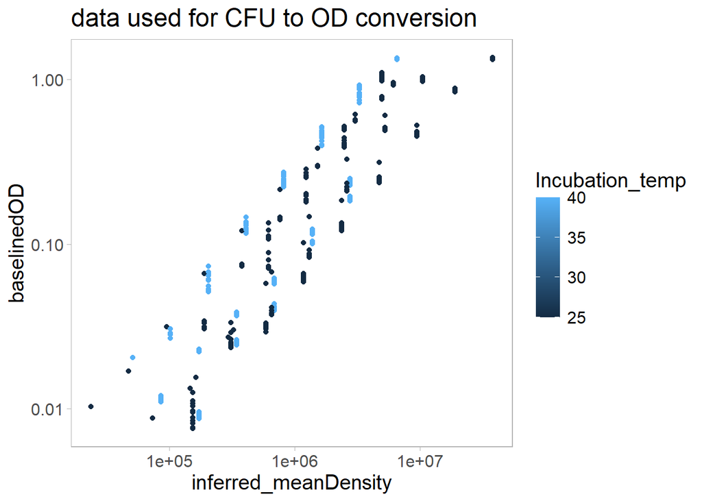

```r
# and again in terms of incubation temperature
ggplot(conversion.data,
       aes(x=inferred_meanDensity, y=baselinedOD, colour=Incubation_temp)) +
  geom_point() +
  scale_y_log10() +
  scale_x_log10() +
  labs(title = "data used for CFU to OD conversion")
```

```r
# a linear model with density as the predictor
CFU_to_OD.lm <- with(conversion.data,
                     lm(log10_OD ~ log10_density))
summary(CFU_to_OD.lm)
```

```
##
## Call:
## lm(formula = log10_OD ~ log10_density)
##
## Residuals:
##      Min       1Q   Median       3Q      Max
## -0.48332 -0.26051 -0.03599  0.25091  0.43137
##
## Coefficients:
##               Estimate Std. Error t value Pr(>|t|)
## (Intercept)   -6.28368    0.14465  -43.44   <2e-16 ***
## log10_density  0.89547    0.02383   37.58   <2e-16 ***
## ---
## Signif. codes:  0 '***' 0.001 '**' 0.01 '*' 0.05 '.' 0.1 ' ' 1
##
## Residual standard error: 0.2701 on 336 degrees of freedom
## Multiple R-squared:  0.8078, Adjusted R-squared:  0.8073
## F-statistic:  1413 on 1 and 336 DF,  p-value: < 2.2e-16
```

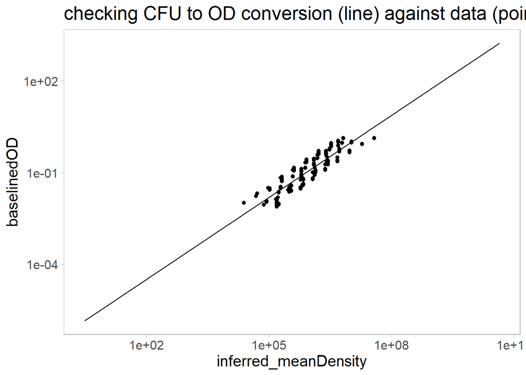

```r
# a function to convert from CFU to OD
convert_CFU_to_OD <- function(CFU) {
  10^(coef(CFU_to_OD.lm)[1] + coef(CFU_to_OD.lm)[2]*log10(CFU))
}

# check what these predictions look like
some_CFU_vals <- seq(from=3.000e+00, to=4.362e+10, length.out=10)
pred_OD <- sapply(some_CFU_vals,
                  convert_CFU_to_OD)

ggplot(conversion.data,
       aes(x=inferred_meanDensity, y=baselinedOD)) +
  geom_point() +
  scale_y_log10() +
  scale_x_log10() +
  geom_line(data=data.frame(some_CFU_vals, pred_OD), aes(x=some_CFU_vals, y=pred_OD)) +
  labs(title = "checking CFU to OD conversion (line) against data (points)")
```

```r
# clean up variables that will not be used in further analyses
rm(all_calib.data, conversion.data, pred_OD, some_CFU_vals)
```

# Analysis of CFU data

Sections I-II from protocols `High-throughput growth curves (exponential phase).docx` and `High-throughput growth curves (stationary phase).docx` where used to create the single-use inoculum ‘shots’. Then, (within 2 months) these shots were plated for CFU estimation by following the protocol `colony forming units (CFU) 6x6 drop plating.docx`.

The CFU data is used to estimate the growth probability at different elevated temperatures (35C and 40C) as compared to normal lab culture conditions for soil bacteria (28C). It’s also used in conjunction with the growth curve data to inform us about the starting concentration of cells in each replicate for the time-to-detection method below, as indicated in [Mytilinaios et al. 2015](https://doi.org/10.1111/jam.12695).

## Load & parse the data

```r
# load the raw data:
CFUraw_survival <- read_excel("./data/CFU_data_2023-12-13.xlsx", sheet="Temp_survival")
# ^^ this is the CFU's at different heat temperatures (35*C & 40*C) as compared to control (28*C). It will be analyzed in this section now.
CFUraw_inocula <- read_excel("./data/CFU_data_2023-12-13.xlsx", sheet="inocula")
# ^^ this is for the estimated inocula of the growth curves. It will be used in the analysis of growth curves below.

# annotate the Samples with their species and strain information
annot.df <- data.frame(Sample = c("BSC001", "BSC002", "BSC003", "BSC004", "BSC005", "BSC006", "BSC007", "BSC008", "BSC009", "BSC010", "BSC015", "BSC019", "CK101", "CK102", "CK103","CK104"),
                       Species = c(rep("P. putida", 3), rep("P. veronii", 3), rep("P. knackmussii", 2), "P. plecoglossicida", rep("P. putida", 2), "P. grimontii", rep("P. protegens", 4)),
                       Strain = c("F1", "KT2440", "uwc 2", rep(NA, 3), "B13", "B14", NA, "mt-2 KT2440", "KT2440", NA, rep("Pf5", 2), rep("CHAO", 2)),
                       Species_in_Expt2 = c(rep(TRUE, 3), rep(TRUE, 3), rep(FALSE, 2), FALSE, rep(TRUE, 2), TRUE, rep(TRUE, 4)))

CFUraw_survival <- inner_join(CFUraw_survival, annot.df, by=c("Sample"))
CFUraw_inocula <- inner_join(CFUraw_inocula, annot.df, by=c("Sample"))

# remove data points where the plate was noted to have dried out
CFUraw_inocula <- CFUraw_inocula[!with(CFUraw_inocula,  grepl("Plate dried out after", Notes)),]

# remove data points where fewer than 15 cells were counted FOR THE 28*C CONTROL condition as these are not trustworthy estimates
CFUraw_survival <- CFUraw_survival %>% filter(CFU_at_28 > 14)

# calculate the survival under the extreme temperatures as a fraction of the density at 28
CFUraw_survival <- CFUraw_survival %>% mutate(survival = CFU_at_stress/CFU_at_28) %>%
                      rename(Temp = Stress_Temp) # rename this column to avoid confusion below

# get mean and bootstrapped confidence intervals
CFU_survival.df <-  CFUraw_survival %>% group_by(Sample, Species, Strain, Temp, Inoculum, Species_in_Expt2) %>%
                       summarise(ci = list(mean_cl_boot(survival) %>%
                          rename(mean_surviv=y, lwr_ci=ymin, upr_ci=ymax))) %>% unnest(cols = c(ci))
```

```
## 'Inoculum'. You can override using the `.groups` argument.
```

```r
# clean up
rm(annot.df)
```

## Which hot temperature has lower CFU?

It’s pretty clear from the plots below that 40C is worse than 35C (…which is why we should always plot the data first XD) but let’s also put some statistics on that.

However, since CFU data is counts, this means that we have to use the Wilcoxon Signed-Rank Test. Which is just as well because the CFU data wasn’t Normally distributed anyway and this test is non-parametric.

```r
# widen the data: CFU at 30C should be in the same row as corresponding CFU at 40C
CFUraw_pairs <- CFUraw_survival %>% select(-survival, -Notes, -`Stress Incubation time (days)`, -Dilution_Counted, -CFU_at_28, -Vol_Plated_mL, -`Incubation time_29 (days)`) %>%
                  unite("uniqPAIR", c(Sample, Inoculum, Replicate), remove=FALSE) %>%
                    pivot_wider(names_from = Temp,
                                names_glue = "{.value}{Temp}",
                                values_from = CFU_at_stress)

# run the test
paired.test <- with(CFUraw_pairs,
                    wilcox.test(CFU_at_stress35, CFU_at_stress40, paired=TRUE))
print(paired.test)
```

```
##
##  Wilcoxon signed rank test with continuity correction
##
## data:  CFU_at_stress35 and CFU_at_stress40
## V = 4159, p-value = 4.022e-14
## alternative hypothesis: true location shift is not equal to 0
```

```r
# clean up
rm(paired.test, CFUraw_pairs)
```

## Does stationary phase protect cells from heat?

Based on the classical microbiology literature, I would expect that stationary phase cultures would be more resistant to high temperatures as compared to exponential phase cultures. Let’s check if there’s a significant effect of the inoculum phase (i.e., exponential or stationary) on the CFU. To do this roughly we will use a two-way ANOVA.

If we were interested in doing this properly, I think it would be better to do a GLMM (Poisson family) on the raw counts data (i.e., the CFUs) at 28C, 35C, and 40C with temperature as a numeric predictor, Inoculum as a categorical predictor, and Species as a random effect…

```r
# convert the columns of the independent variables to factors
CFUraw_survival$Temp <- as.factor(CFUraw_survival$Temp)
CFUraw_survival$Species <- as.factor(CFUraw_survival$Species)
CFUraw_survival$Inoculum <- as.factor(CFUraw_survival$Inoculum)

# no interaction
survival.anova.2way <- aov(survival ~ Inoculum + Species + Temp, data = CFUraw_survival)
# check the model:
#plot(survival.anova.2way)
# the residuals could look better (large residuals for intermediate values) but it's acceptable

# all possible interactions
survival.anova.ALLinteractions <- aov(survival ~ Inoculum * Species * Temp, data = CFUraw_survival)
# check the model:
#plot(survival.anova.ALLinteractions)
# this looks a bit worse than above

# use AIC to select the preferred model
model.set <- list(survival.anova.2way, survival.anova.ALLinteractions)
model.names <- c("two.way", "interaction")
aictab(model.set, modnames = model.names)
```

|  | Modnames | K | AICc | Delta_AICc | ModelLik | AICcWt | LL | Cum.Wt |
| --- | --- | --- | --- | --- | --- | --- | --- | --- |
| 2 | interaction | 25 | -15.64863 | 0.0000 | 1.000000e+00 | 1.000000e+00 | 36.83666 | 1 |
| 1 | two.way | 9 | 103.14550 | 118.7941 | 1.600225e-26 | 1.600225e-26 | -42.06713 | 1 |

```r
# display the results
summary(survival.anova.ALLinteractions)
```

```
##                        Df Sum Sq Mean Sq F value   Pr(>F)
## Inoculum                1  0.291   0.291   6.420  0.01222 *
## Species                 5 18.113   3.623  79.869  < 2e-16 ***
## Temp                    1  9.650   9.650 212.749  < 2e-16 ***
## Inoculum:Species        5  3.187   0.637  14.051 1.96e-11 ***
## Inoculum:Temp           1  0.015   0.015   0.329  0.56678
## Species:Temp            5  5.805   1.161  25.595  < 2e-16 ***
## Inoculum:Species:Temp   5  0.775   0.155   3.419  0.00576 **
## Residuals             164  7.439   0.045
## ---
## Signif. codes:  0 '***' 0.001 '**' 0.01 '*' 0.05 '.' 0.1 ' ' 1
```

```r
#TukeyHSD(survival.anova.ALLinteractions) # don't print this because it's very long and not so meaningful

# clean up
rm(survival.anova.2way, survival.anova.ALLinteractions, model.set, model.names)
```

So there’s a very slight effect of inoculum phase, but this is definitely less important than the effect of species. In fact, it seems that the inoculum effect actually interacts with the species. Neat!

## Plot CFU data

```r
# re-order the Species for appropriate colour plotting
CFU_survival.df$Species <- factor(CFU_survival.df$Species,
                                  levels=c("P. veronii", "P. grimontii", "P. plecoglossicida", "P. protegens", "P. knackmussii", "P. putida"))
# for appropriate labelling of the facet with degree symbol, create a factorial version of Temp
CFU_survival.df$temp_as_factor <- factor(CFU_survival.df$Temp)
levels(CFU_survival.df$temp_as_factor) <- c("thirtyfive", "forty")
# for plotting little skulls to emphasize lack of growth
CFU_survival.df$Shape <- ifelse(CFU_survival.df$mean_surviv==0, "\u2620", "\u25cf")
plot.CFU_survivalEXP <- CFU_survival.df %>% filter(Inoculum == "Exponential") %>%
                          arrange(Temp, Species)
plot.CFU_survivalSTA <- CFU_survival.df %>% filter(Inoculum == "Stationary") %>%
                          arrange(Temp, Species)

print("exponential phase plot below:")
```

```
## [1] "exponential phase plot below:"
```

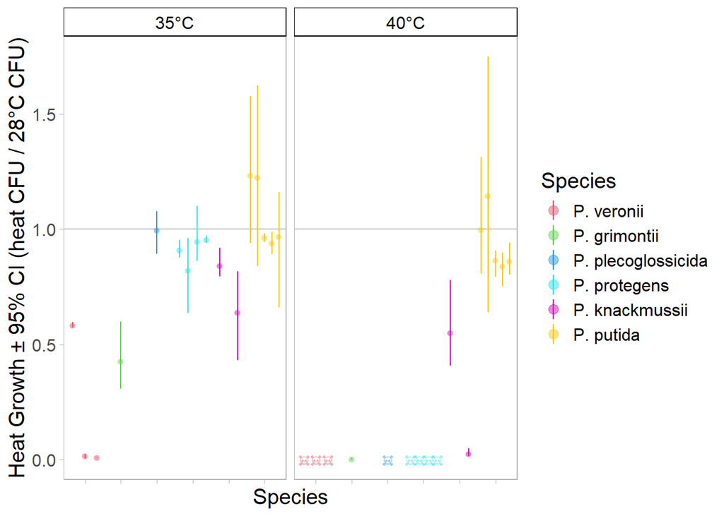

```r
# plot the exponential phase data with Temp as rows
#ggplot(CFU_survival.df %>% filter(Inoculum == "Exponential"),
#       aes(y=mean_surviv, x=Species, colour=Species)) +
#  facet_grid(temp_as_factor ~ .,
#             labeller = as_labeller(c(thirtyfive='35\u00b0C',
#                                      forty='40\u00b0C'))) +
#  geom_hline(yintercept = 1, colour="grey") +
#  geom_point(position = position_dodge2(width = 0.8, preserve = "single"), alpha=0.5, shape=plot.CFU_survivalEXP$Shape, size=3) +
#  geom_linerange(aes(ymin=lwr_ci, ymax=upr_ci), position = position_dodge2(width = 0.8, preserve = "single")) +
#  scale_colour_manual(values=ALLsp_palette) +
#  theme(axis.text.x=element_text(angle = 60, hjust = 0.95)) +
#  labs(y="Effect Size (CFU stress/CFU 28*C)") +
#  theme(strip.background = element_rect(fill = "white", colour="black"),
#        strip.text = element_text(color = "black"))

# plot the exponential phase data again but with Temp as columns
ggplot(CFU_survival.df %>% filter(Inoculum == "Exponential"),
       aes(y=mean_surviv, x=Species, colour=Species)) +
  facet_wrap(. ~ temp_as_factor,
             labeller = as_labeller(c(thirtyfive='35\u00b0C',
                                      forty='40\u00b0C'))) +
  geom_hline(yintercept = 1, colour="grey") +
  geom_point(position = position_dodge2(width = 1), alpha=0.5, shape=plot.CFU_survivalEXP$Shape, size=3) +
  geom_linerange(aes(ymin=lwr_ci, ymax=upr_ci), position = position_dodge2(width = 1)) +
  scale_colour_manual(values=ALLsp_palette) +
  theme(axis.text.x=element_text(angle = 60, hjust = 0.95)) +
  labs(y="Heat Growth ± 95% CI (heat CFU / 28\u00b0C CFU)") +
  theme(strip.background = element_rect(fill = "white", colour="black"),
        strip.text = element_text(color = "black"),
        #axis.title.y = element_text(size = 12),
        axis.text.x=element_blank())
```

```r
# high quality figure for manuscript main text
png(filename="Fig2_B.png", width = 4.63, height = 4.4, units = "in", res=300)
ggplot(CFU_survival.df %>% filter(Inoculum == "Exponential"),
       aes(y=mean_surviv, x=Species, colour=Species)) +
  facet_wrap(. ~ temp_as_factor,
             labeller = as_labeller(c(thirtyfive='35\u00b0C',
                                      forty='40\u00b0C'))) +
  geom_hline(yintercept = 1, colour="grey") +
  geom_point(position = position_dodge2(width = 1), alpha=0.5, shape=plot.CFU_survivalEXP$Shape, size=3) +
  geom_linerange(aes(ymin=lwr_ci, ymax=upr_ci), position = position_dodge2(width = 1)) +
  scale_colour_manual(values=ALLsp_palette) +
  theme(axis.text.x=element_text(angle = 60, hjust = 0.95)) +
  labs(y="Heat Growth ± 95% CI (heat CFU / 28\u00b0C CFU)") +
  theme(strip.background = element_rect(fill = "white", colour="black"),
        strip.text = element_text(color = "black"),
        #axis.title.y = element_text(size = 12),
        axis.text.x=element_blank(),
        legend.position = "none")
dev.off()
```

```r
print("stationary phase plot below:")
```

```
## [1] "stationary phase plot below:"
```

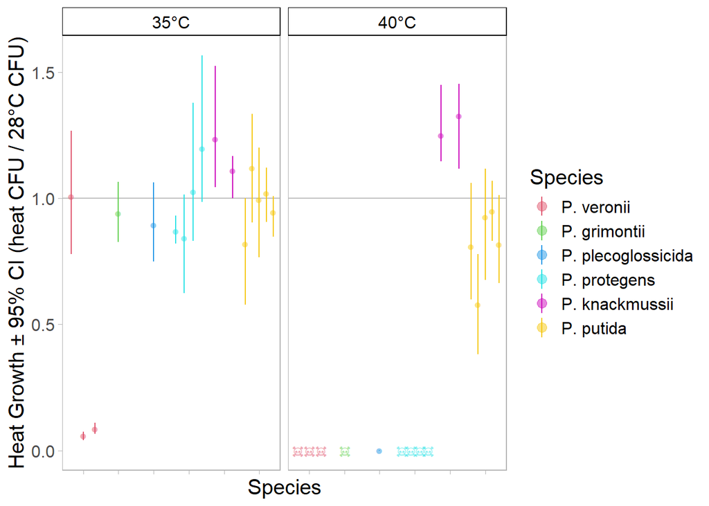

```r
# plot the stationary phase data with Temp as columns
ggplot(CFU_survival.df %>% filter(Inoculum == "Stationary"),
       aes(y=mean_surviv, x=Species, colour=Species)) +
  facet_wrap(. ~ temp_as_factor,
             labeller = as_labeller(c(thirtyfive='35\u00b0C',
                                      forty='40\u00b0C'))) +
  geom_hline(yintercept = 1, colour="grey") +
  geom_point(position = position_dodge2(width = 1), alpha=0.5, shape=plot.CFU_survivalSTA$Shape, size=3) +
  geom_linerange(aes(ymin=lwr_ci, ymax=upr_ci), position = position_dodge2(width = 1)) +
  scale_colour_manual(values=ALLsp_palette) +
  theme(axis.text.x=element_text(angle = 60, hjust = 0.95)) +
  labs(y="Heat Growth ± 95% CI (heat CFU / 28\u00b0C CFU)") +
  theme(strip.background = element_rect(fill = "white", colour="black"),
        strip.text = element_text(color = "black"),
        #axis.title.y = element_text(size = 12),
        axis.text.x=element_blank())
```

```r
# clean up
rm(plot.CFU_survivalEXP, plot.CFU_survivalSTA, CFUraw_survival)
```

# Analysis of growth curves

Analysis of growth curve data that was generated by following the protocols `High-throughput growth curves (exponential phase).docx` and `High-throughput growth curves (stationary phase).docx`.

By growing bacteria from a serial dilution, it is possible to estimate their intrinsic growth rate ($\mu$) by measuring the inoculum size and the time it takes for each dilution to cross some threshold (“time-to-detection”, abbreviated TTD), then rearranging the simple exponential growth equation $N_t = N_0e^{\mu t}$. It’s also possible to see if there’s a lag time and to test if other models are a better fit to the data. See [Mytilinaios et al. 2015](https://doi.org/10.1111/jam.12695). Remember that TTD is inversely related to growth rate: a fast growing strain will have a shorter TTD and a slow growing strain will have a longer TTD.

The calibration curve, CFUs, and heat growth data above are incorporated into the analysis.

## Load & parse data

Load the data using the function `get_ODdata_block` defined in “H1_extract_data_fun_v3-1.R”. Note that pairs of replicate plates that were run on the same day (i.e., “blocks”) can be loaded together in the same function call with the date as the block ID. The OD data for each well is loaded. Also, the temperature measured at each time-point by the instrument is given as the mean over the entire growth curve rounded to the nearest integer.

*Exclusion of contaminated wells:* make sure that you exclude any contaminated wells from the data BEFORE exporting to text file. You will have to do this by noting which wells have unexpected fluorescence emission via fluorescent scanning of the plate with the BioTek H1 Synergy multimodal plate reader at the end of the growth curve.

```r
#, eval=FALSE}

# this function runs with some warnings. Hermina looked over the resultant data.frame and it seems fine. Will fix this if they find some time...

# load the data
# list.files(pattern = 'C\\.txt$')


# Exponential Phase Inoculum

EX1raw_data.df <- get_ODdata_block(blockID = "2023-10-30",
                                filename_1 = "./data/2023-10-30_12strains_30C.txt",
                                filename_2 = "./data/2023-10-30_12strains_40C.txt")

EX2raw_data.df <- get_ODdata_block(blockID = "2023-11-01",
                                filename_1 = "./data/2023-11-01_12strains_25C.txt",
                                filename_2 = "./data/2023-11-01_12strains_35C.txt")

EX3raw_data.df <- get_ODdata_block(blockID = "2023-11-03",
                                filename_1 = "./data/2023-11-03_12strains_30C.txt",
                                filename_2 = "./data/2023-11-03_12strains_40C.txt")

EX4raw_data.df <- get_ODdata_block(blockID = "2023-11-06",
                                filename_1 = "./data/2023-11-06_12strains_25C.txt",
                                filename_2 = "./data/2023-11-06_12strains_35C.txt")

EX5raw_data.df <- get_ODdata_block(blockID = "2023-11-08",
                                filename_1 = "./data/2023-11-08_12strains_30C.txt")
```

```
## [1] "Only loading 1 file for block 2023-11-08"
```

```r
# error with 2023-11-08_12strains_40C.txt
  # when extract_OD_df splits the lines strings on tab and then tries to coerce them into a matrix, R complains that "data length [27354] is not a sub-multiple or multiple of the number of columns [98]"
  # I can't find the issue and Excel can't either
  # so just load this one file from csv
  broken_txt <- read.csv("./data/2023-11-08_12strains_40C.csv")
  # convert the wide data into long tidy data as usually done by get_OD_data
  broken_txt$Time <- sapply(broken_txt$Time,
                            function(x) as.numeric(hms(x))/(60*60))
  # now we can easily convert the whole data.frame to numeric
  broken_txt[] <- lapply(broken_txt, as.numeric)
  # convert Temp into the mean temperature across the run
  broken_txt$Temp <- round(mean(broken_txt$Temp), digits=1)
  # reshape the data to long format
  broken_txt <- pivot_longer(broken_txt, cols=!c("Time", "Temp"), names_to="Well", values_to="OD")
  # add block and plate columns
  broken_txt$block <- "2023-11-08"
  broken_txt$plate <- 2
  # combine it with data from the rest of its corresponding block
    # first need to change Temp factor back to numeric
  EX5raw_data.df$Temp <- as.numeric(as.character(EX5raw_data.df$Temp))
  EX5raw_data.df <- rbind(EX5raw_data.df, broken_txt)
    # then change it back to a factor to prevent downstream issues
  EX5raw_data.df$Temp <- as.factor(EX5raw_data.df$Temp)
  rm(broken_txt)

EX6raw_data.df <- get_ODdata_block(blockID = "2023-11-10",
                                filename_1 = "./data/2023-11-10_12strains_25C.txt")
```

```
## [1] "Only loading 1 file for block 2023-11-10"
```

```r
                                # there's no 2023-11-10_12strains_35C.txt because this file got corrupted

# Stationary Phase Inoculum

ST1raw_data.df <- get_ODdata_block(blockID = "2023-11-13",
                                filename_1 = "./data/2023-11-13_12strains_25C.txt",
                                filename_2 = "./data/2023-11-13_12strains_35C.txt")

ST2raw_data.df <- get_ODdata_block(blockID = "2023-11-20",
                                filename_1 = "./data/2023-11-20_12strains_30C.txt",
                                filename_2 = "./data/2023-11-20_12strains_40C.txt")

ST3raw_data.df <- get_ODdata_block(blockID = "2023-11-15",
                                filename_1 = "./data/2023-11-15_12strains_25C.txt",
                                filename_2 = "./data/2023-11-15_12strains_35C.txt")

ST4raw_data.df <- get_ODdata_block(blockID = "2023-11-22",
                                filename_1 = "./data/2023-11-22_12strains_30C.txt",
                                filename_2 = "./data/2023-11-22_12strains_40C.txt")

ST5raw_data.df <- get_ODdata_block(blockID = "2023-11-17",
                                filename_1 = "./data/2023-11-17_12strains_25C.txt",
                                filename_2 = "./data/2023-11-17_12strains_35C.txt")

ST6raw_data.df <- get_ODdata_block(blockID = "2023-11-24",
                                filename_1 = "./data/2023-11-24_12strains_30C.txt",
                                filename_2 = "./data/2023-11-24_12strains_40C.txt")
```

Annotate the data using the function `annotate_data` defined in “H1_extract_data_fun_v3-1.R”. The option `layout = "12columns"` assumes the data is composed of 12 samples laid out over columns 1-12 and rows B-G are assumed to be a dilution series from $10^{-1}$ to $10^{-6}$ (rows A & H are assumed to be blank).

```r
#, eval=FALSE}

# define vectors for each of the 3 layouts
layout1 = c("Pseudomonas putida KT2440 - mScarlet","Pseudomonas putida uwc 2 - BFP","Pseudomonas putida F1 - sYFP","Pseudomonas veronii - mScarlet","Pseudomonas knackmussii B14 - GFP","Pseudomonas plecoglossicida - NA","Pseudomonas veronii - mCherry","Pseudomonas putida mt-2 KT2440 - NA","Pseudomonas veronii - BFP","Pseudomonas knackmussii B13 - mCherry","Pseudomonas putida KT2440 - GFP","Pseudomonas grimontii - NA")
layout2 = c("Pseudomonas veronii - mCherry","Pseudomonas veronii - BFP","Pseudomonas putida mt-2 KT2440 - NA","Pseudomonas knackmussii B13 - mCherry","Pseudomonas putida KT2440 - GFP","Pseudomonas grimontii - NA","Pseudomonas putida KT2440 - mScarlet","Pseudomonas putida F1 - sYFP","Pseudomonas putida uwc 2 - BFP","Pseudomonas veronii - mScarlet","Pseudomonas knackmussii B14 - GFP","Pseudomonas plecoglossicida - NA")
layout3 = c("Pseudomonas veronii - mScarlet","Pseudomonas knackmussii B14 - GFP","Pseudomonas plecoglossicida - NA","Pseudomonas putida KT2440 - mScarlet","Pseudomonas putida uwc 2 - BFP","Pseudomonas putida F1 - sYFP","Pseudomonas knackmussii B13 - mCherry","Pseudomonas grimontii - NA","Pseudomonas putida KT2440 - GFP","Pseudomonas veronii - mCherry","Pseudomonas veronii - BFP","Pseudomonas putida mt-2 KT2440 - NA")

# annotate the data for each raw data.frame
# Exponential Phase Inoculum

EX1raw_data.df <- annotate_data(EX1raw_data.df, layout = "12columns", samples=layout1)
EX2raw_data.df <- annotate_data(EX2raw_data.df, layout = "12columns", samples=layout1)
EX3raw_data.df <- annotate_data(EX3raw_data.df, layout = "12columns", samples=layout2)
EX4raw_data.df <- annotate_data(EX4raw_data.df, layout = "12columns", samples=layout2)
EX5raw_data.df <- annotate_data(EX5raw_data.df, layout = "12columns", samples=layout3)
EX6raw_data.df <- annotate_data(EX6raw_data.df, layout = "12columns", samples=layout3)

# Stationary Phase Inoculum

ST1raw_data.df <- annotate_data(ST1raw_data.df, layout = "12columns", samples=layout1)
ST2raw_data.df <- annotate_data(ST2raw_data.df, layout = "12columns", samples=layout1)
ST3raw_data.df <- annotate_data(ST3raw_data.df, layout = "12columns", samples=layout2)
ST4raw_data.df <- annotate_data(ST4raw_data.df, layout = "12columns", samples=layout2)
ST5raw_data.df <- annotate_data(ST5raw_data.df, layout = "12columns", samples=layout3)
ST6raw_data.df <- annotate_data(ST6raw_data.df, layout = "12columns", samples=layout3)

# combine exponential replicates into one data.frame
exponential.df <- rbind(EX1raw_data.df, EX2raw_data.df, EX3raw_data.df, EX4raw_data.df, EX5raw_data.df, EX6raw_data.df)
exponential.df$Inoculum <- "Exponential"
# combine stationary replicates into one data.frame
stationary.df <- rbind(ST1raw_data.df, ST2raw_data.df, ST3raw_data.df, ST4raw_data.df, ST5raw_data.df, ST6raw_data.df)
stationary.df$Inoculum <- "Stationary"

# combine all replicates into one giant data.frame
ALLraw_data.df <- rbind(exponential.df, stationary.df)
# remove the column titled Replicate as it is meaningless
ALLraw_data.df <- ALLraw_data.df %>% select(-Replicate)

# create a unique ID for each growth curve by pasting block, plate, and well
ALLraw_data.df$uniqID <- with(ALLraw_data.df, paste(Well, plate, block, Inoculum))

# the time column is giving very stupid and meaningless values because of division by 3
# round to nearest second
ALLraw_data.df$Time <- round(ALLraw_data.df$Time, digits = 4)

# the Gen5 program inserted ** around the values that Anjaney excluded as outliers.
  # this leads to NA values that lead to downstream problems
# loop through all uniqID's to identify and remove replicates that are all NAs
for(curve in unique(ALLraw_data.df$uniqID)){
  df <- ALLraw_data.df %>% filter(uniqID == curve)
  if(all(is.na(df$OD))){ # identify replicates where all OD values are NA
    ALLraw_data.df <-ALLraw_data.df %>% filter(uniqID != curve)
  }
}
# cleanup
rm(df, curve)

# change all Temp==26 values into 25 because that's our treatment
ALLraw_data.df$Temp <- as.numeric(as.character(ALLraw_data.df$Temp))
ALLraw_data.df$Temp[which(ALLraw_data.df$Temp==26)] <- 25

# to keep your work space clean, you can now delete the many data.frames containing the individual blocks
rm(EX1raw_data.df, EX2raw_data.df, EX3raw_data.df, EX4raw_data.df, EX5raw_data.df, EX6raw_data.df, ST1raw_data.df, ST2raw_data.df, ST3raw_data.df, ST4raw_data.df, ST5raw_data.df, ST6raw_data.df, layout1, layout2, layout3, exponential.df, stationary.df)
```

(Note that here plate 1 corresponds with H1 Synergy and plate 2 corresponds with Epoch.)

The P. protegens data was acquired by Hermina in Spring 2024, after Anjaney left. Load that data now:

```r
#, eval=FALSE}

# load the data as separate data.frames
PpEXP1raw_data.df <- get_ODdata_block(blockID = "2024-03-13",
                                      filename_1 = "./data/Pprotegens_exponential_40C--13March24.txt",
                                      filename_2 = "./data/Pprotegens_exponential_35C--13March24.txt")
PpEXP2raw_data.df <- get_ODdata_block(blockID = "2024-03-11",
                                      filename_1 = "./data/Pprotegens_exponential_30C--11March24.txt",
                                      filename_2 = "./data/Pprotegens_exponential_25C--11March24.txt")
PpSTA1raw_data.df <- get_ODdata_block(blockID = "2024-03-15",
                                      filename_1 = "./data/Pprotegens_stationary_40C--15March24.txt",
                                      filename_2 = "./data/Pprotegens_stationary_30C--15March24.txt")
PpSTA2raw_data.df <- get_ODdata_block(blockID = "2024-03-18",
                                      filename_1 = "./data/Pprotegens_stationary_35C--18March24.txt",
                                      filename_2 = "./data/Pprotegens_stationary_25C--18March24.txt")

# annotate the data
layout1 <- c(rep("Pseudomonas protegens Pf5 - mTourquoise", 3), rep("Pseudomonas protegens Pf5 - mCherry", 3), rep("Pseudomonas protegens CHAO - GFP", 3), rep("Pseudomonas protegens CHAO - mCherry", 3))
layout2 <- c(rep(c("Pseudomonas protegens Pf5 - mCherry", "Pseudomonas protegens CHAO - GFP", "Pseudomonas protegens CHAO - mCherry", "Pseudomonas protegens Pf5 - mTourquoise"), times=2), "Pseudomonas protegens Pf5 - mCherry", "Pseudomonas protegens Pf5 - mTourquoise", "Pseudomonas protegens CHAO - mCherry", "Pseudomonas protegens CHAO - GFP")
layout3 <- rep(c("Pseudomonas protegens Pf5 - mTourquoise","Pseudomonas protegens Pf5 - mCherry","Pseudomonas protegens CHAO - GFP","Pseudomonas protegens CHAO - mCherry"), times=3)

# annotate the data for each raw data.frame
# Exponential Phase Inoculum
PpEXP1raw_data.df <- annotate_data(PpEXP1raw_data.df, layout = "12columns", samples=layout1)
PpEXP2raw_data.df <- annotate_data(PpEXP2raw_data.df, layout = "12columns", samples=layout2)
# Stationary Phase Inoculum
PpSTA1raw_data.df <- annotate_data(PpSTA1raw_data.df, layout = "12columns", samples=layout3)
PpSTA2raw_data.df <- annotate_data(PpSTA2raw_data.df, layout = "12columns", samples=layout2)

# combine exponential replicates into one data.frame
exponential.df <- rbind(PpEXP1raw_data.df, PpEXP2raw_data.df)
exponential.df$Inoculum <- "Exponential"
# combine stationary replicates into one data.frame
stationary.df <- rbind(PpSTA1raw_data.df, PpSTA2raw_data.df)
stationary.df$Inoculum <- "Stationary"

# combine all replicates into one giant data.frame
Ppraw_data.df <- rbind(exponential.df, stationary.df)
# remove the column titled Replicate as it is meaningless
Ppraw_data.df <- Ppraw_data.df %>% select(-Replicate)

# create a unique ID for each growth curve by pasting block, plate, and well
Ppraw_data.df$uniqID <- with(Ppraw_data.df, paste(Well, plate, block, Inoculum))

# the time column is giving very stupid and meaningless values because of division by 3
# round to nearest second
Ppraw_data.df$Time <- round(Ppraw_data.df$Time, digits = 4)

# the Gen5 program inserted ** around the values that Anjaney excluded as outliers.
  # this leads to NA values that lead to downstream problems
# loop through all uniqID's to identify and remove replicates that are all NAs
for(curve in unique(Ppraw_data.df$uniqID)){
  df <- Ppraw_data.df %>% filter(uniqID == curve)
  if(all(is.na(df$OD))){ # identify replicates where all OD values are NA
    Ppraw_data.df <- Ppraw_data.df %>% filter(uniqID != curve)
  }
}
# cleanup
rm(df, curve)

# change all Temp==26 values into 25 because that's our treatment
Ppraw_data.df$Temp <- as.numeric(as.character(Ppraw_data.df$Temp))
Ppraw_data.df$Temp[which(Ppraw_data.df$Temp==26)] <- 25

# combine the P. protegens data with the rest of the data...
ALLraw_data.df <- rbind(ALLraw_data.df, Ppraw_data.df)

# clean up
rm(PpEXP1raw_data.df, PpEXP2raw_data.df, PpSTA1raw_data.df, PpSTA2raw_data.df, annotate_data, extract_OD_df, get_OD_data, get_ODdata_block, layout1, layout2, layout3, exponential.df, stationary.df, Ppraw_data.df)
```

Do the baseline subtraction to get the OD values: baseline subtract using the median OD value of the blanks for each time point, for each plate.

Then let’s plot the baseline subtracted data OD for all culture phases, samples, and temperatures. The colours show growth curves with different dilutions, from $10^{-1}$ to $10^{-6}$ (note that these come from different batches, i.e., that were grown on different days). The black horizontal line shows the detection threshold (baselined OD = 0.05) that is used for the TTD analysis below.

```r
#, eval=FALSE}
# baseline subtract using the median OD value of the blanks for each time point, for each plate
  # create a data.frame containing only the blank samples for all plates
data.blanks <- ALLraw_data.df %>% filter(Sample=="BLK")
  # calculate the median OD value for the blanks at each time point for each plate.
medianOD <- data.blanks %>% group_by(Time, block, plate) %>% # group the blanks together for each time point and plate
                summarise(medianBlankOD = median(OD, na.rm=TRUE)) # get median OD value
  # put the data.blanks information back into the full dataset
ALL_data.df <- inner_join(ALLraw_data.df %>% filter(Sample!="BLK"), # remove blank samples
                             medianOD)
```

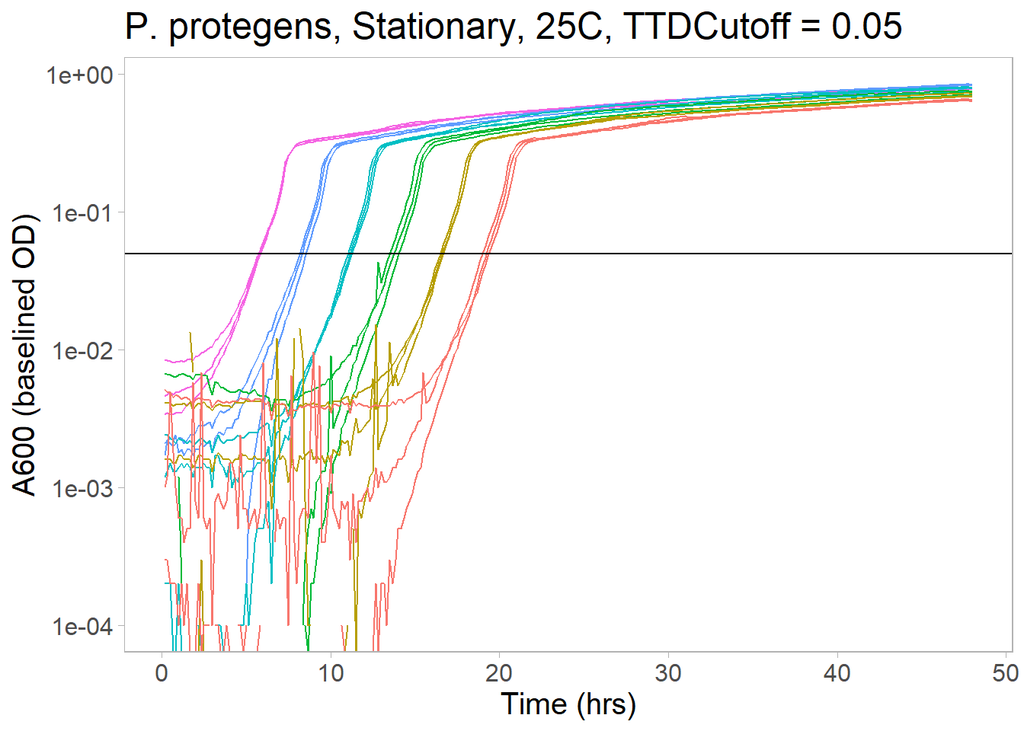

```r
  # Finally, do the baseline subtraction by subtracting the medianBlankOD from the OD values
ALL_data.df$baselinedOD <- ALL_data.df$OD - ALL_data.df$medianBlankOD


# plot the data
ggplot(filter(ALL_data.df, Sample == "Pseudomonas protegens Pf5 - mTourquoise", Inoculum == "Stationary", Temp == "25"),
       aes(y= baselinedOD, x=Time, colour=Dilution, group=uniqID )) +
  scale_y_log10() +
  geom_line() +
  geom_hline(yintercept =  0.05) +
  theme(legend.position = "none") +
  labs(title="P. protegens, Stationary, 25C, TTDCutoff = 0.05", x="Time (hrs)", y="A600 (baselined OD)")
```

```r
# it's possible to plot all the data by uncommenting the following block of code:
#for(phase in unique(ALL_data.df$Inoculum)){
# for(smpls in levels(ALL_data.df$Sample)[levels(ALL_data.df$Sample) != "BLK"]){
#   for(temps in unique(ALL_data.df$Temp)) {
#      temp_data_for_plotting <- ALL_data.df %>%
#                                  filter(Inoculum == phase,
#                                         Sample == smpls,
#                                         Temp == temps)
#      plot <- ggplot(temp_data_for_plotting,
#                     aes(y = baselinedOD, x = Time, colour = Dilution, group = uniqID)) +
#              scale_y_log10() +
#              geom_line() +
#              geom_hline(yintercept =  0.05) +
#              theme(legend.position = "none") +
#              labs(title = paste0(phase, " at ", temps, "*C, ", smpls),
#                   x="Time (hrs)", y="A600 (baselined OD)")
#      print(plot)
#   }
# }
#}

# clean-up
rm(data.blanks, medianOD, plot, temp_data_for_plotting, phase, smpls, temps)
```

Okay, now that that’s sorted, we can proceed with the analysis…

Improve on the annotation of the Samples to create dedicated columns for species, strain, and fluorescence and also to add the sample ID in the TERR collection.

Then, let’s see how many data points we have for all samples and treatments…

Note that due to some error with the plate reader, the 3rd replicate of 35*C (in block 2023-11-10) was corrupted so we’re missing those data points :(

```r
#, eval=FALSE}
# parse the details stored in the Sample column into dedicated columns...
ALL_data.df$temp_Sample <- as.character(ALL_data.df$Sample)
# separate the species, strain, and fluorophore information from the unique sample names
ALL_data.df <- ALL_data.df %>% separate(col=temp_Sample, sep=" - ", into=c("Genotype", "Fluor"))
# parse the Genotype column into a species column
ALL_data.df$Species <- sub("Pseudomonas (\\w+)", "\\1",
                    str_extract(ALL_data.df$Genotype, "Pseudomonas (\\w+)"))
ALL_data.df$Species <- paste("P.", ALL_data.df$Species)
# For some samples, we have additional strain information. Parse this from the Genotype column into a strain column
ALL_data.df$Strain <- NA
ALL_data.df$Strain[as.logical(str_count(ALL_data.df$Genotype, "\\w+\\s\\w+\\s.*"))] <- sub("(\\S+\\s+){2}(.*)", "\\2", ALL_data.df$Genotype[as.logical(str_count(ALL_data.df$Genotype, "\\w+\\s\\w+\\s.*"))])

# Replace the information in the Sample column with the unique sample ID from our strain collection
ALL_data.df$Sample <- as.character(ALL_data.df$Sample)
ALL_data.df$Sample[ALL_data.df$Sample == "Pseudomonas putida F1 - sYFP"] <- "BSC001"
ALL_data.df$Sample[ALL_data.df$Sample == "Pseudomonas putida KT2440 - mScarlet"] <- "BSC002"
ALL_data.df$Sample[ALL_data.df$Sample == "Pseudomonas putida uwc 2 - BFP"] <- "BSC003"
ALL_data.df$Sample[ALL_data.df$Sample == "Pseudomonas veronii - BFP"] <- "BSC004"
ALL_data.df$Sample[ALL_data.df$Sample == "Pseudomonas veronii - mScarlet"] <- "BSC005"
ALL_data.df$Sample[ALL_data.df$Sample == "Pseudomonas veronii - mCherry"] <- "BSC006"
ALL_data.df$Sample[ALL_data.df$Sample == "Pseudomonas knackmussii B13 - mCherry"] <- "BSC007"
ALL_data.df$Sample[ALL_data.df$Sample == "Pseudomonas knackmussii B14 - GFP"] <- "BSC008"
ALL_data.df$Sample[ALL_data.df$Sample == "Pseudomonas plecoglossicida - NA"] <- "BSC009"
ALL_data.df$Sample[ALL_data.df$Sample == "Pseudomonas putida mt-2 KT2440 - NA"] <- "BSC010"
ALL_data.df$Sample[ALL_data.df$Sample == "Pseudomonas putida KT2440 - GFP"] <- "BSC015"
ALL_data.df$Sample[ALL_data.df$Sample == "Pseudomonas grimontii - NA"] <- "BSC019"
ALL_data.df$Sample[ALL_data.df$Sample == "Pseudomonas protegens Pf5 - mTourquoise"] <- "CK101"
ALL_data.df$Sample[ALL_data.df$Sample == "Pseudomonas protegens Pf5 - mCherry"] <- "CK102"
ALL_data.df$Sample[ALL_data.df$Sample == "Pseudomonas protegens CHAO - GFP"] <- "CK103"
ALL_data.df$Sample[ALL_data.df$Sample == "Pseudomonas protegens CHAO - mCherry"] <- "CK104"
# remove the genotype column
ALL_data.df <- ALL_data.df %>% select(-Genotype)

# check that all the data we loaded is actually there
check_data <- ALL_data.df %>% filter(Time < 0.2) %>%
                group_by(Sample, Temp, Dilution, Inoculum) %>%
                  summarise(Count=n()) %>%
                    arrange(Inoculum, Sample, Temp, desc(Dilution)) %>% as.data.frame()
# let's take a peak at the df...
check_data
```

| Sample | Temp | Dilution | Inoculum | Count |
| --- | --- | --- | --- | --- |
| BSC001 | 25 | 0.1 | Exponential | 3 |
| BSC001 | 25 | 0.01 | Exponential | 3 |
| BSC001 | 25 | 0.001 | Exponential | 3 |
| BSC001 | 25 | 1e-04 | Exponential | 3 |
| BSC001 | 25 | 1e-05 | Exponential | 3 |
| BSC001 | 25 | 1e-06 | Exponential | 3 |
| BSC001 | 30 | 0.1 | Exponential | 3 |
| BSC001 | 30 | 0.01 | Exponential | 3 |
| BSC001 | 30 | 0.001 | Exponential | 3 |
| BSC001 | 30 | 1e-04 | Exponential | 3 |

[output cut: 758 more lines]

```r
# okay that table is waaaaay too long, let's see an overview of it:
summary(check_data)
```

```
##     Sample               Temp        Dilution     Inoculum
##  Length:768         Min.   :25.00   1e-06:128   Length:768
##  Class :character   1st Qu.:28.75   1e-05:128   Class :character
##  Mode  :character   Median :32.50   1e-04:128   Mode  :character
##                     Mean   :32.50   0.001:128
##                     3rd Qu.:36.25   0.01 :128
##                     Max.   :40.00   0.1  :128
##      Count
##  Min.   :2.000
##  1st Qu.:3.000
##  Median :3.000
##  Mean   :2.891
##  3rd Qu.:3.000
##  Max.   :3.000
```

```r
# 35*C in block 2023-11-10 was corrupted so that's why we're missing those data points
# Display all data that have fewer than 3 replicates
check_data %>% filter(Count < 3)
```

| Sample | Temp | Dilution | Inoculum | Count |
| --- | --- | --- | --- | --- |
| BSC001 | 35 | 0.1 | Exponential | 2 |
| BSC001 | 35 | 0.01 | Exponential | 2 |
| BSC001 | 35 | 0.001 | Exponential | 2 |
| BSC001 | 35 | 1e-04 | Exponential | 2 |
| BSC001 | 35 | 1e-05 | Exponential | 2 |
| BSC001 | 35 | 1e-06 | Exponential | 2 |
| BSC002 | 35 | 0.1 | Exponential | 2 |
| BSC002 | 35 | 0.01 | Exponential | 2 |
| BSC002 | 35 | 0.001 | Exponential | 2 |
| BSC002 | 35 | 1e-04 | Exponential | 2 |

[output cut: 74 more lines]

```r
# cleanup
rm(check_data, ALLraw_data.df)
```

## Data processing: Approximate the TTD

See from the data plots above (and Anjaney’s presentation) that a baselined OD value of 0.05 is a reasonable cut-off for the time-to-detection (TTD) such that all curves are still in exponential growth at this value (i.e., growth is linear when plotted on a log scale). However, this low value doesn’t work properly for wells whose baseline from the start of the experiment just happened to be higher than 0.05. That’s why I’m also setting a high TTD value of 0.13 for comparison.

We will use kernel smoothing to get a more fine-grained approximation for the TTD and find the exact time when the threshold is passed (i.e., as compared to Anjaney’s presentation, where he got a coarse-grained estimate of the TTD by finding the first sampled time point when baselined OD > 0.05).

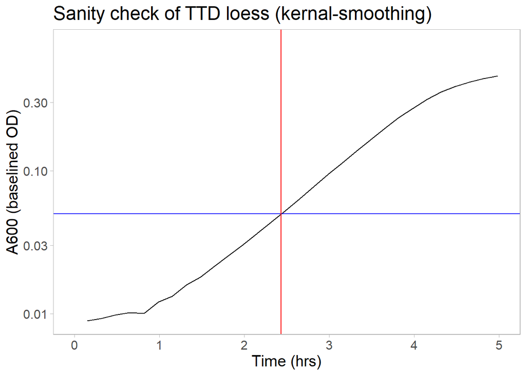

```r
#, eval=FALSE}
# set the cut-off to 0.05 because this is the value that Anjaney found where all growth curves are still in the "log-linear" phase.
TTDcutoff.low <- 0.05

tempdf <- ALL_data.df %>% filter(uniqID == "B1 1 2023-10-30 Exponential")
# perform linear interpolation using OD as the independent variable and Time as the dependent
tempdf.Time <- approx(y=tempdf$Time, x=tempdf$baselinedOD,
                      xout=TTDcutoff.low, ties="mean")$y #when there are non-unique values for baselinedOD, it takes the mean across these (that's why I'm NOT using the log of baselinedOD because then ties would be resolved using the geometric mean and I don't want that)

# plot to check that this is working properly
ggplot(tempdf,
       aes(y= baselinedOD, x=Time)) +
  scale_y_log10() +
  geom_line() +
  xlim(0,5) +
  geom_hline(yintercept =  TTDcutoff.low, col="blue") +
  geom_vline(xintercept =  tempdf.Time, col="red") +
  theme(legend.position = "none") +
  labs(title="Sanity check of TTD loess (kernal-smoothing)", x="Time (hrs)", y="A600 (baselined OD)")
```

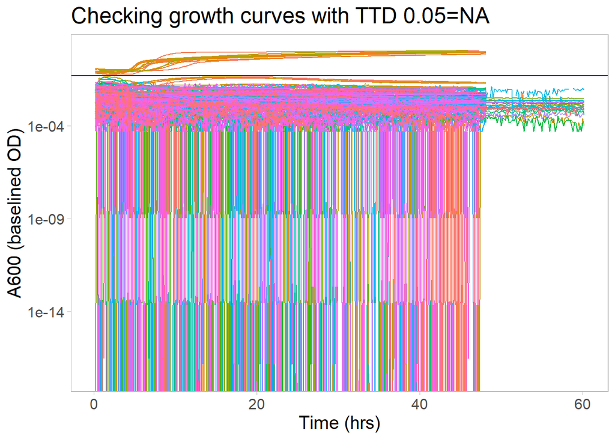

```r
rm(tempdf, tempdf.Time)

# initialize an empty data.frame for storage
TTD.df <- ALL_data.df %>% select(-Time, -Well, -OD, -medianBlankOD, -baselinedOD) %>% distinct()
TTD.df$TTD <- NA

# loop through all uniqID's
for(curve in unique(ALL_data.df$uniqID)) {
  # calculate the detection time using interpolation
  detect_t <- with(ALL_data.df %>% filter(uniqID == curve),
                   approx(y=Time, x=baselinedOD, xout=TTDcutoff.low, ties="mean")$y)
  # save the time to the storage data.frame
  TTD.df$TTD[TTD.df$uniqID == curve] <- detect_t
}
rm(curve, detect_t)

# check that NA values for TTD correspond with curves that failed to grow
  # keep OD values for the unique ID's that have TTD equal to NA
tempdf <- ALL_data.df %>% filter(uniqID %in% TTD.df$uniqID[is.na(TTD.df$TTD)])
ggplot(tempdf,
       aes(y = baselinedOD, x = Time, colour = uniqID, group = uniqID)) +
  scale_y_log10() +
  geom_line() +
  #xlim(0,5) +
  geom_hline(yintercept =  TTDcutoff.low, col="blue") +
  theme(legend.position = "none") +
  labs(title="Checking growth curves with TTD 0.05=NA", x="Time (hrs)", y="A600 (baselined OD)")
```

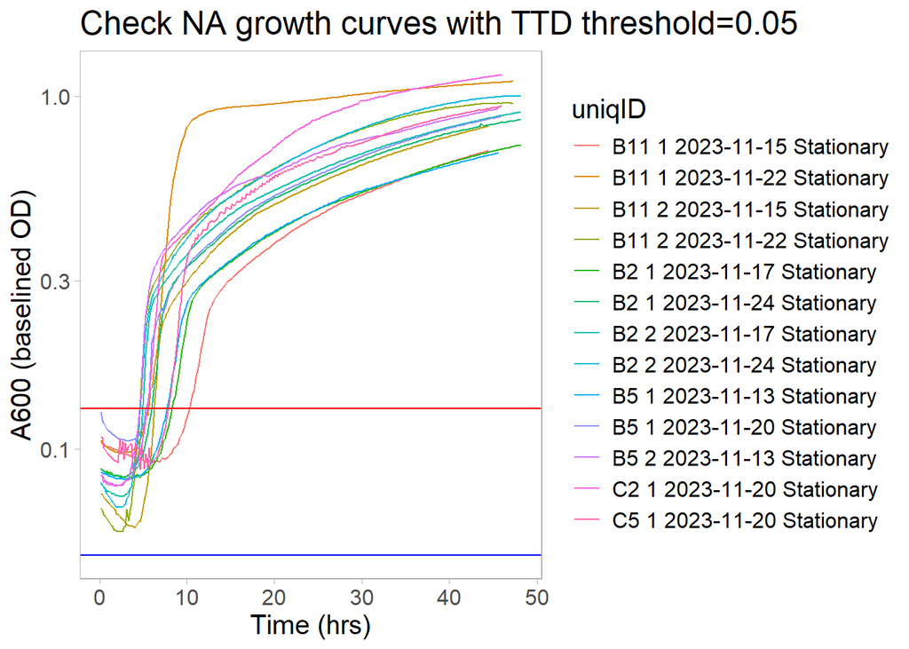

```r
ggplot(tempdf[which(tempdf$baselinedOD > TTDcutoff.low),],
       aes(y = baselinedOD, x = Time, colour = uniqID, group = uniqID)) +
  scale_y_log10() +
  geom_line() +
  geom_hline(yintercept =  TTDcutoff.low, col="blue") +
  geom_hline(yintercept =  0.13, col="red") +
  labs(title="Check NA growth curves with TTD threshold=0.05", x="Time (hrs)", y="A600 (baselined OD)")
```

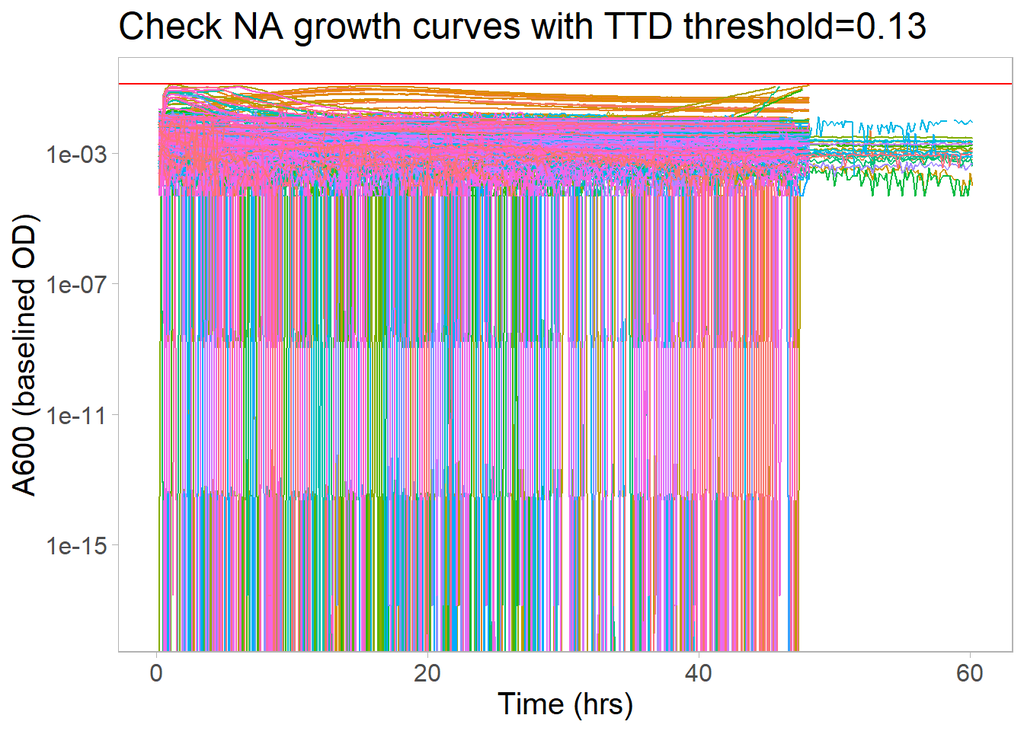

```r
# let's repeat the TTD value calculation for slightly higher TTD cutoff where all growth curves can be included

# rename the first TTD value calculation in the storage data.frame
TTD.df <- TTD.df %>% rename(TTD_0.05 = TTD)

# define the higher TTD cutoff value and initialize storage vector
TTDcutoff.hi <- 0.13
TTD.df$TTD_0.13 <- NA

# loop through all uniqID's
for(curve in unique(ALL_data.df$uniqID)) {
  # calculate the detection time using interpolation
  detect_t <- with(ALL_data.df %>% filter(uniqID == curve),
                   approx(y=Time, x=baselinedOD, xout=TTDcutoff.hi, ties="mean")$y)
  # save the time to the storage data.frame
  TTD.df$TTD_0.13[TTD.df$uniqID == curve] <- detect_t
}

# check again that the NA TTD values represent growth curves that failed to grow
tempdf <- ALL_data.df %>% filter(uniqID %in% TTD.df$uniqID[is.na(TTD.df$TTD_0.13)])
ggplot(tempdf,
       aes(y = baselinedOD, x = Time, colour = uniqID, group = uniqID)) +
  scale_y_log10() +
  geom_line() +
  #xlim(0,5) +
  geom_hline(yintercept =  TTDcutoff.hi, col="red") +
  theme(legend.position = "none") +
  labs(title="Check NA growth curves with TTD threshold=0.13", x="Time (hrs)", y="A600 (baselined OD)")
```

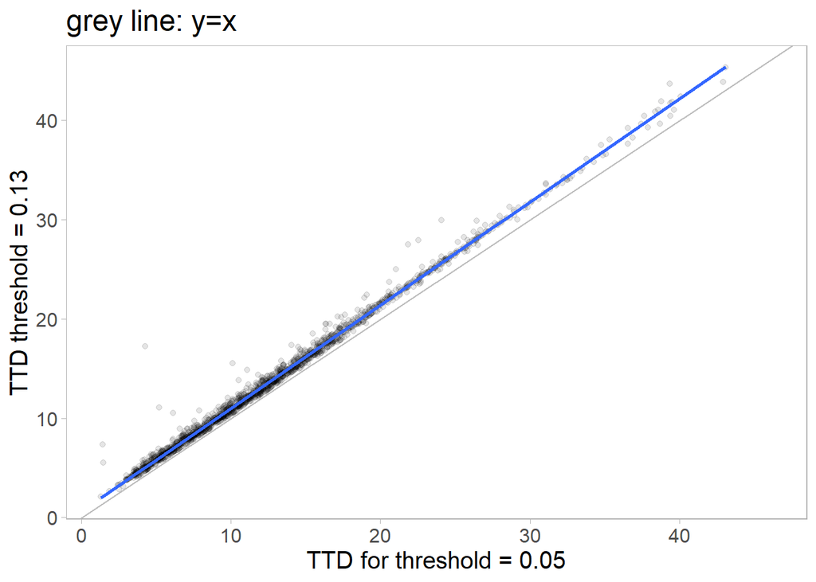

```r
# check for agreement in the growth rates estimated by the 2 thresholds
ggplot(TTD.df, aes(x=TTD_0.05, y=TTD_0.13)) +
  geom_abline(slope=1, intercept=0, colour="grey") +
  geom_point(alpha=0.1) +
  geom_smooth(se=FALSE, method="lm") +
  labs(x="TTD for threshold = 0.05", y="TTD threshold = 0.13",
       title="grey line: y=x")
```

```r
# display the correlation:
summary(lm(TTD.df$TTD_0.13 ~ TTD.df$TTD_0.05))
```

```
##
## Call:
## lm(formula = TTD.df$TTD_0.13 ~ TTD.df$TTD_0.05)
##
## Residuals:
##     Min      1Q  Median      3Q     Max
## -1.3278 -0.2861 -0.0842  0.1609 12.2079
##
## Coefficients:
##                 Estimate Std. Error t value Pr(>|t|)
## (Intercept)     0.602497   0.029144   20.67   <2e-16 ***
## TTD.df$TTD_0.05 1.038598   0.002043  508.30   <2e-16 ***
## ---
## Signif. codes:  0 '***' 0.001 '**' 0.01 '*' 0.05 '.' 0.1 ' ' 1
##
## Residual standard error: 0.5878 on 1736 degrees of freedom
##   (482 observations deleted due to missingness)
## Multiple R-squared:  0.9933, Adjusted R-squared:  0.9933
## F-statistic: 2.584e+05 on 1 and 1736 DF,  p-value: < 2.2e-16
```

```r
# save this intermediate data to output for reproducibility & easy loading in downstream analyses
#save(ALL_data.df, TTD.df,
#     file="all_growthcurve_data.RData")

#clean up
rm(curve, detect_t, tempdf, TTDcutoff.hi, TTDcutoff.low)
```

It seems that the lower TTD value (0.05) is good for most of the growth curves but there are a couple of growth curves that start with too high OD, even after baselining. That’s why I tried setting a higher TTD value (0.13). The problem with this higher value is that we lose some of the growth curves that only cross this threshold later in growth. *shrug* This is not a perfect method… But hopefully we can make some reasonable interpretations.

Below we can see that although bigger values are systematically estimated for TTD when the cut-off is bigger, there’s actually very good correlation between the estimates. In general I will prefer the lower cut-off value (0.05).

### Check concordance of batch culture & CFU data

Before we combine the TTD data with the inoculum sizes from the CFU data, let’s convince ourselves that these two types of data are generally in agreement with one another. Use the data from both the higher and the lower TTD cutoffs as a binary indicator of growth (i.e., if we failed to find you at both cutoffs, then we assume that you didn’t grow at all). AKA survival at different temperatures. Then we will compare the binary indicator of growth with whether growth was observed or not by CFU.

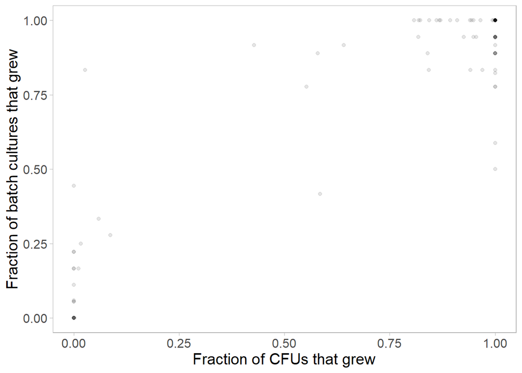

```r
#load("all_growthcurve_data.RData")

binary_survival <- TTD.df %>% filter(Temp > 25)

# convert the data TTD data into binary survival for both thresholds
binary_survival$TTD_0.05  <- !is.na(binary_survival$TTD_0.05)
binary_survival$TTD_0.13  <- !is.na(binary_survival$TTD_0.13)
# let's condense the TTD binary data by assuming that if you returned TRUE in either of the thresholds, then you grew.
# this is more conservative than strictly requiring growth in both TTD's...
binary_survival$TTD <- binary_survival$TTD_0.05 | binary_survival$TTD_0.13

# summarize the binary growth data into fraction of all replicates when growth was observed
binary_survival <- binary_survival %>% select(Sample, Species, Temp, Inoculum, Dilution, TTD) %>% # keep just the meta-data and the TTD binary survival
                    group_by(Sample, Temp, Inoculum) %>%
                      summarise(fraction_batch=mean(TTD))
# combine the fraction of growing batch cultures with the CFU data
temp_CFUsurviv <- CFU_survival.df %>% ungroup() %>% select(Sample, Temp, Inoculum, mean_surviv)
temp_CFUsurviv <- rbind(temp_CFUsurviv,
                        temp_CFUsurviv[temp_CFUsurviv$Temp == 35, ] %>% mutate(Temp = 30, mean_surviv = 1))
binary_survival <- inner_join(binary_survival,
                              temp_CFUsurviv,
                              by = c("Temp", "Sample", "Inoculum"))

# CFU growth > 1 is not particularly meaningful for this analysis
  # this assumption is pretty reasonable as the 95% CI overlaps with 1.0
  # for all species anyway, except for stationary phase P. knackmussii
binary_survival$mean_surviv[binary_survival$mean_surviv > 1] <- 1

ggplot(binary_survival,
       aes(x=mean_surviv, y=fraction_batch)) +
  geom_point(alpha=0.1) +
  labs(x="Fraction of CFUs that grew",
       y="Fraction of batch cultures that grew")
```

```r
# display the correlation:
summary(lm(binary_survival$fraction_batch ~ binary_survival$mean_surviv))
```

```
##
## Call:
## lm(formula = binary_survival$fraction_batch ~ binary_survival$mean_surviv)
##
## Residuals:
##      Min       1Q   Median       3Q      Max
## -0.47740 -0.08852  0.02260  0.04469  0.64635
##
## Coefficients:
##                             Estimate Std. Error t value Pr(>|t|)
## (Intercept)                  0.16504    0.02974   5.549 2.64e-07 ***
## binary_survival$mean_surviv  0.81237    0.03605  22.535  < 2e-16 ***
## ---
## Signif. codes:  0 '***' 0.001 '**' 0.01 '*' 0.05 '.' 0.1 ' ' 1
##
## Residual standard error: 0.1449 on 94 degrees of freedom
## Multiple R-squared:  0.8438, Adjusted R-squared:  0.8421
## F-statistic: 507.8 on 1 and 94 DF,  p-value: < 2.2e-16
```

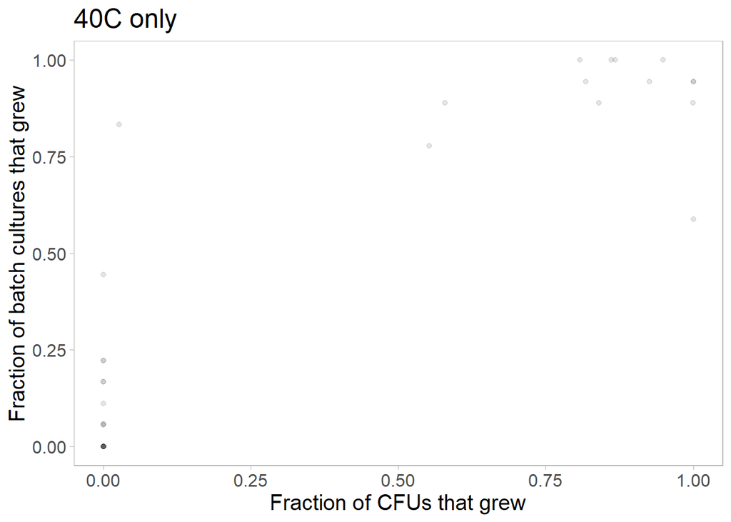

```r
# let's also check specifically the data at 40C, as this is where the cultures fail to grow and so this temperature is likely to be most problematic
binary_survival40 <- binary_survival %>% filter(Temp == 40)
ggplot(binary_survival40,
       aes(x=mean_surviv, y=fraction_batch)) +
  geom_point(alpha=0.1) +
  labs(x="Fraction of CFUs that grew",
       y="Fraction of batch cultures that grew",
       title="40C only")
```

```r
# display the correlation:
summary(lm(binary_survival40$fraction_batch ~ binary_survival40$mean_surviv))
```

```
##
## Call:
## lm(formula = binary_survival40$fraction_batch ~ binary_survival40$mean_surviv)
##
## Residuals:
##      Min       1Q   Median       3Q      Max
## -0.42361 -0.13411 -0.04520  0.08923  0.67552
##
## Coefficients:
##                               Estimate Std. Error t value Pr(>|t|)
## (Intercept)                    0.13411    0.04357   3.078  0.00443 **
## binary_survival40$mean_surviv  0.87774    0.07827  11.215 2.97e-12 ***
## ---
## Signif. codes:  0 '***' 0.001 '**' 0.01 '*' 0.05 '.' 0.1 ' ' 1
##
## Residual standard error: 0.1913 on 30 degrees of freedom
## Multiple R-squared:  0.8074, Adjusted R-squared:  0.801
## F-statistic: 125.8 on 1 and 30 DF,  p-value: 2.968e-12
```

```r
# clean up
rm(temp_CFUsurviv, binary_survival, binary_survival40)
```

Batch culture and CFU data are not exactly the same but they tend to be in good agreement ($R^2 \approx 0.84$).

Next we will combine the estimated inoculum sizes with the TTD data in order to infer the growth rate.

```r
# calculate the concentration of the cryostocked inoculum in the absence of stress (i.e, 28*C)
inoc_data <- CFUraw_inocula %>% filter(Temp == 28) %>% select(-Temp) %>%
            mutate(Concentration = CFU/Vol_Plated_mL * 1/Dilution_Counted)

# get mean and bootstrapped confidence intervals for the cryostocked inoculum density
inoc_data <- inoc_data %>% group_by(Sample, Inoculum, Species, Strain, Species_in_Expt2) %>%
                summarise(ci = list(mean_cl_boot(Concentration) %>%
                  rename(mean_inoc_den=y, lwrCI_inoc_den=ymin, uprCI_inoc_den=ymax))) %>% unnest(cols = c(ci))
```

```
## You can override using the `.groups` argument.
```

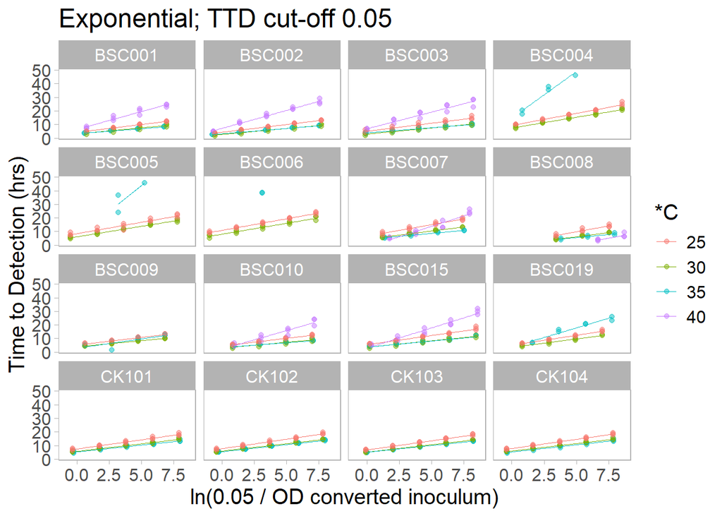

```r
# now use the mean survival rates from CFU_survival.df to estimate the inoculum density at different temperatures
temp_CFUsurviv <- CFU_survival.df %>% select(-temp_as_factor, -Shape)
# assume that 25*C and 30*C have the same cell counts as 28*C ... in other words, survival = 1
temp_CFUsurviv$Temp <- temp_CFUsurviv$Temp - 10
temp_CFUsurviv$mean_surviv <- temp_CFUsurviv$lwr_ci <- temp_CFUsurviv$upr_ci <- 1
temp_CFUsurviv <- rbind(CFU_survival.df %>% select(-temp_as_factor, -Shape),
                        temp_CFUsurviv)
# combine the CFU survival data with the inoculum density data
inoc_data <- inner_join(inoc_data, temp_CFUsurviv,
                        by=c("Sample", "Species", "Strain", "Inoculum", "Species_in_Expt2"))
# finally, multiply the inoculum density with the CFU survival
inoc_data <- inoc_data %>%
                mutate(mean_inoc_den = mean_inoc_den * mean_surviv,
                       lwrCI_inoc_den = lwrCI_inoc_den * lwr_ci,
                       uprCI_inoc_den = uprCI_inoc_den * upr_ci) %>%
                  select(-mean_surviv, -lwr_ci, -upr_ci)

# infer the inoculum density estimates for the dilution series
inoc_data <- do.call("rbind", replicate(6, inoc_data, simplify = FALSE))
inoc_data$Dilution <- rep(10^(-1*(1:6)), each=nrow(inoc_data)/6)
  # calculate the mean N0
inoc_data <- inoc_data %>%
                mutate(mean_N0 = mean_inoc_den * Dilution,
                       lwrCI_N0 = lwrCI_inoc_den * Dilution,
                       uprCI_N0 = uprCI_inoc_den * Dilution) %>%
                  select(-mean_inoc_den, -lwrCI_inoc_den, -uprCI_inoc_den)

# combine the data sets
  # convert columns to compatible classes between the 2 data frames
TTD.df$Dilution <- as.numeric(levels(TTD.df$Dilution))[TTD.df$Dilution]
TTD.df <- inner_join(TTD.df, inoc_data,
                     by=c("Temp", "Sample", "Inoculum", "Species", "Strain", "Dilution"))

# exclude growth curves that started with fewer than 20 cells (too much stochasticity)
TTD.df <- TTD.df %>% filter(mean_N0 > 20)

###############################
# convert TTD into growth rate estimates
###############################

# estimate ln(N_t / N_0) in units of OD
TTD.df$inferredOD_meanN0 <- sapply(TTD.df$mean_N0,
                                   convert_CFU_to_OD)
TTD.df <- TTD.df %>% mutate(ln_Ntsmall_over_N0 = log(0.05 / inferredOD_meanN0),
                          ln_Ntbig_over_N0 = log(0.13 / inferredOD_meanN0))

ggplot(TTD.df %>% filter(Inoculum=="Exponential"),
          aes(x = ln_Ntsmall_over_N0, y = TTD_0.05, group=Temp, colour=as.factor(Temp))) +
        facet_wrap(vars(Sample)) +
        geom_point(alpha=0.5) +
        geom_smooth(se=FALSE, method="lm", size=0.2) +
        labs(title="Exponential; TTD cut-off 0.05",
             x="ln(0.05 / OD converted inoculum)",
             y="Time to Detection (hrs)",
             colour="*C")
```

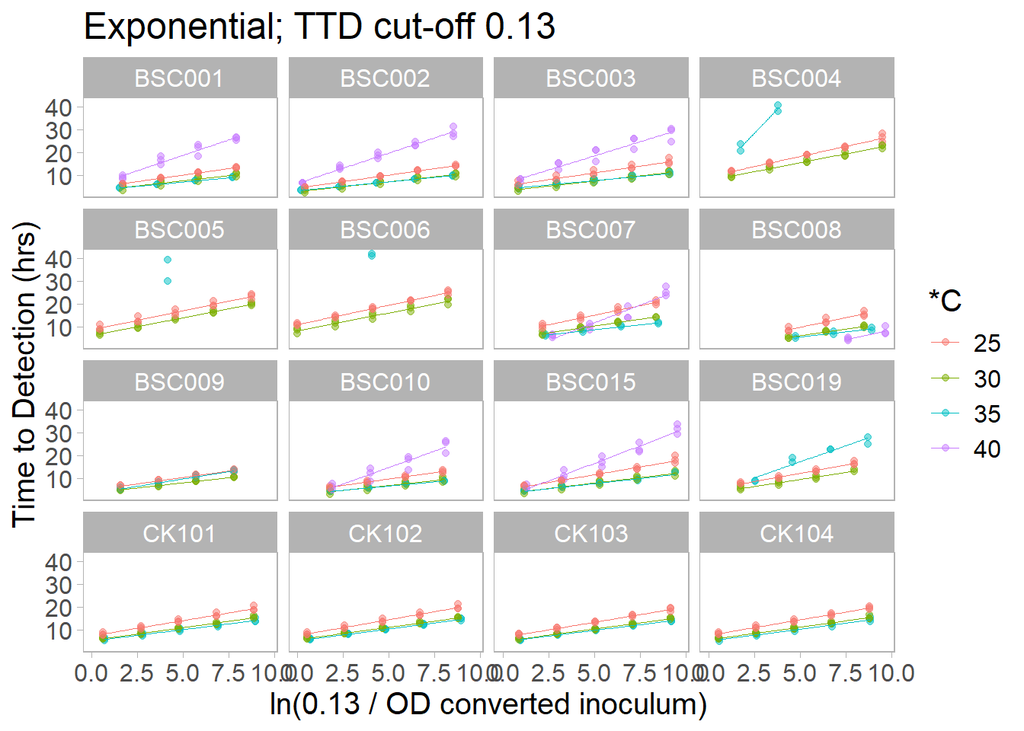

```r
ggplot(TTD.df %>% filter(Inoculum=="Exponential"),
          aes(x=ln_Ntbig_over_N0, y=TTD_0.13, group=Temp, colour=as.factor(Temp))) +
        facet_wrap(vars(Sample)) +
        geom_point(alpha=0.5) +
        geom_smooth(se=FALSE, method="lm", size=0.2) +
        labs(title="Exponential; TTD cut-off 0.13",
             x="ln(0.13 / OD converted inoculum)",
             y="Time to Detection (hrs)",
             colour="*C")
```

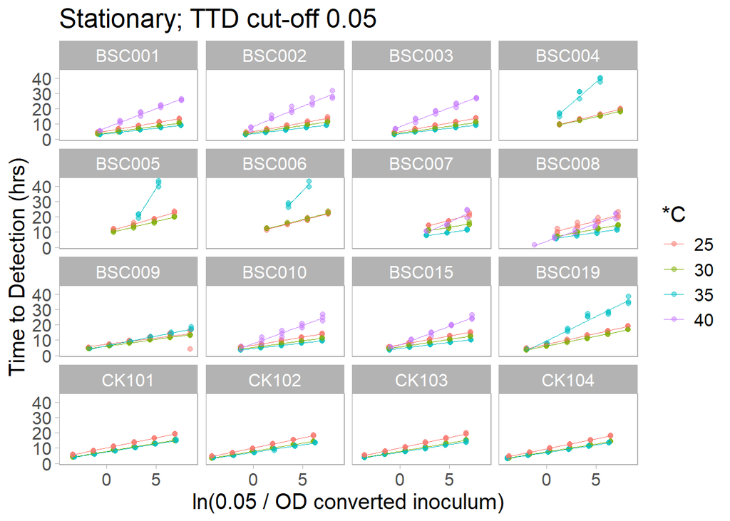

```r
ggplot(TTD.df %>% filter(Inoculum=="Stationary"),
          aes(x=ln_Ntsmall_over_N0, y=TTD_0.05, group=Temp, colour=as.factor(Temp))) +
        facet_wrap(vars(Sample)) +
        geom_point(alpha=0.5) +
        geom_smooth(se=FALSE, method="lm", size=0.2) +
        labs(title="Stationary; TTD cut-off 0.05",
             x="ln(0.05 / OD converted inoculum)",
             y="Time to Detection (hrs)",
             colour="*C")
```

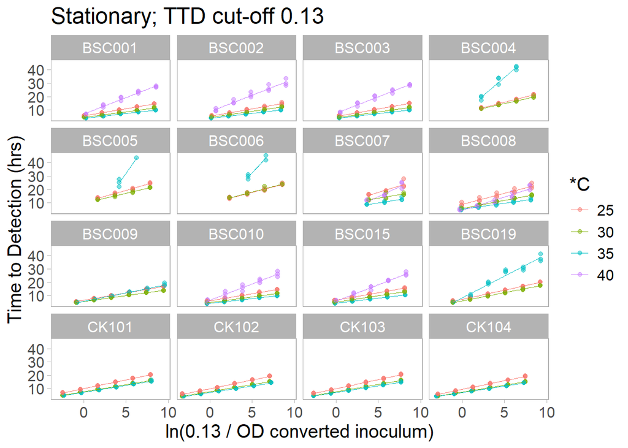

```r
ggplot(TTD.df %>% filter(Inoculum=="Stationary"),
          aes(x=ln_Ntbig_over_N0, y=TTD_0.13, group=Temp, colour=as.factor(Temp))) +
        facet_wrap(vars(Sample)) +
        geom_point(alpha=0.5) +
        geom_smooth(se=FALSE, method="lm", size=0.2) +
        labs(title="Stationary; TTD cut-off 0.13",
             x="ln(0.13 / OD converted inoculum)",
             y="Time to Detection (hrs)",
             colour="*C")
```

```r
## EVERYTHING LOOKS GOOD SO NOW WE CAN ACTUALLY FIT THE LM'S AND EXTRACT SUMMARY STATISTICS FROM THEM:

# initialize variable for storage
Dil_growthrates.df <- data.frame(matrix(nrow=0, ncol=11))

# calculate the slope, sd, and r-squared of the slope
for(sam in unique(TTD.df$Sample)){
  for(t in unique(TTD.df$Temp)){
    for(inoc in unique(TTD.df$Inoculum)){

      temp.df <- TTD.df %>% filter(Sample==sam, Temp==t, Inoculum==inoc)
      if(sum(temp.df$mean_N0, na.rm=TRUE)>0 # if CFU data indicates cells can survive
          &                                     # and
         sum(!is.na(temp.df$TTD_0.05))>4){      # there are 5 or more non-NA TTD values

        # fit the linear model on ln(N_t / N_0) for N0 converted from CFU to OD
        tmpOD_lm <- lm(TTD_0.05 ~ ln_Ntsmall_over_N0, temp.df)
        # bootstrap the data to get the 95% CI of the slope
        tmpOD_boot <- bootSlope(TTD_0.05 ~ ln_Ntsmall_over_N0, data = temp.df,
                                B = 1000, plot.hist = FALSE)

        # estimate biomass growth rate from WITHOUT taking into account inocula CFU
        tmp_lm <- lm(TTD_0.05 ~ log10(Dilution), temp.df)
        # bootstrap the data to get the 95% CI of the slope
        tmp_boot <- bootSlope(TTD_0.05 ~ log10(Dilution), data = temp.df,
                              B = 1000, plot.hist = FALSE)

        # store the values
        Dil_growthrates.df <- rbind(Dil_growthrates.df,
                                    c(sam, t, inoc,

                                      # summary statistics for the lm with converted OD
                                      unname(1/coef(tmpOD_lm)[2]), # mean growth rate
                                      unname(1/(quantile(tmpOD_boot, probs = 0.975,
                                                         na.rm = TRUE))), # lower 95% CI of growth rate
                                      unname(1/(quantile(tmpOD_boot, probs = 0.025,
                                                         na.rm = TRUE))), # upper 95% CI of growth rate
                                      summary(tmpOD_lm)$r.squared, # multiple R-squared

                                      # also get the summary statistics for the lm on raw CFU
                                      unname(exp(coef(tmp_lm)[2])), # mean growth rate
                                      unname(exp(quantile(tmp_boot, probs = 0.025,
                                                          na.rm = TRUE))), # lower 95% CI of growth rate
                                      unname(exp(quantile(tmp_boot, probs = 0.975,
                                                          na.rm = TRUE))), # upper 95% CI of growth rate
                                      summary(tmp_lm)$r.squared) # multiple R-squared
                                    )
      }
      if(sum(temp.df$mean_N0, na.rm=TRUE)==0 # if CFU data indicates cells CANNOT survive
          |                                      # or
         sum(!is.na(temp.df$TTD_0.05))<5){       # if there are less than 5 non-NA TTD values
        # store 0 values
        Dil_growthrates.df <- rbind(Dil_growthrates.df,
                                    c(sam, t, inoc, rep(0, 8))
                                    )
        # initialize variables to avoid unnecessary warnings
        tmp_lm <- tmp_boot <- tmpOD_lm <- tmpOD_boot <- NA
      }
      rm(tmp_lm, tmp_boot, temp.df, tmpOD_lm, tmpOD_boot)
    }
  }
}
```

```
##
##   1 observation(s) removed due to missing values.
##
##   1 observation(s) removed due to missing values.
##
##   3 observation(s) removed due to missing values.
```

```
##
##   3 observation(s) removed due to missing values.
```

```
##
##   4 observation(s) removed due to missing values.
##
##   4 observation(s) removed due to missing values.
```

```
##
##   2 observation(s) removed due to missing values.
##
##   2 observation(s) removed due to missing values.
##
##   3 observation(s) removed due to missing values.
##
##   3 observation(s) removed due to missing values.
```

```
##
##   3 observation(s) removed due to missing values.
##
##   3 observation(s) removed due to missing values.
##
##   4 observation(s) removed due to missing values.
```

```
##
##   4 observation(s) removed due to missing values.
```

```
##
##   3 observation(s) removed due to missing values.
```

```
##
##   3 observation(s) removed due to missing values.
```

```
##
##   3 observation(s) removed due to missing values.
##
##   3 observation(s) removed due to missing values.
```

```
##
##   1 observation(s) removed due to missing values.
##
##   1 observation(s) removed due to missing values.
```

```r
# update the column names
colnames(Dil_growthrates.df) <- c("Sample", "Temp", "Inoculum",
                                  "mu", "mu_lwrCI", "mu_uprCI", "r_sq",
                                  "biomass_mu", "biomass_mu_lwrCI", "biomass_mu_uprCI", "biomass_rsq")
# change Temp to a numeric from character
Dil_growthrates.df$Temp <- as.numeric(Dil_growthrates.df$Temp)
# change mu to a numeric from character
Dil_growthrates.df$mu <- as.numeric(Dil_growthrates.df$mu)
Dil_growthrates.df$biomass_mu <- as.numeric(Dil_growthrates.df$biomass_mu)
# change mu_lwrCI to a numeric from character
Dil_growthrates.df$mu_lwrCI <- as.numeric(Dil_growthrates.df$mu_lwrCI)
Dil_growthrates.df$biomass_mu_lwrCI <- as.numeric(Dil_growthrates.df$biomass_mu_lwrCI)
# change mu_uprCI to a numeric from character
Dil_growthrates.df$mu_uprCI <- as.numeric(Dil_growthrates.df$mu_uprCI)
Dil_growthrates.df$biomass_mu_uprCI <- as.numeric(Dil_growthrates.df$biomass_mu_uprCI)
# change r_sq to a numeric from character
Dil_growthrates.df$r_sq <- as.numeric(Dil_growthrates.df$r_sq)
Dil_growthrates.df$biomass_rsq <- as.numeric(Dil_growthrates.df$biomass_rsq)
# add species/strain annotation
Dil_growthrates.df <- left_join(Dil_growthrates.df,
                                TTD.df %>% select(Sample, Species, Strain, Fluor, Species_in_Expt2) %>% distinct())
```

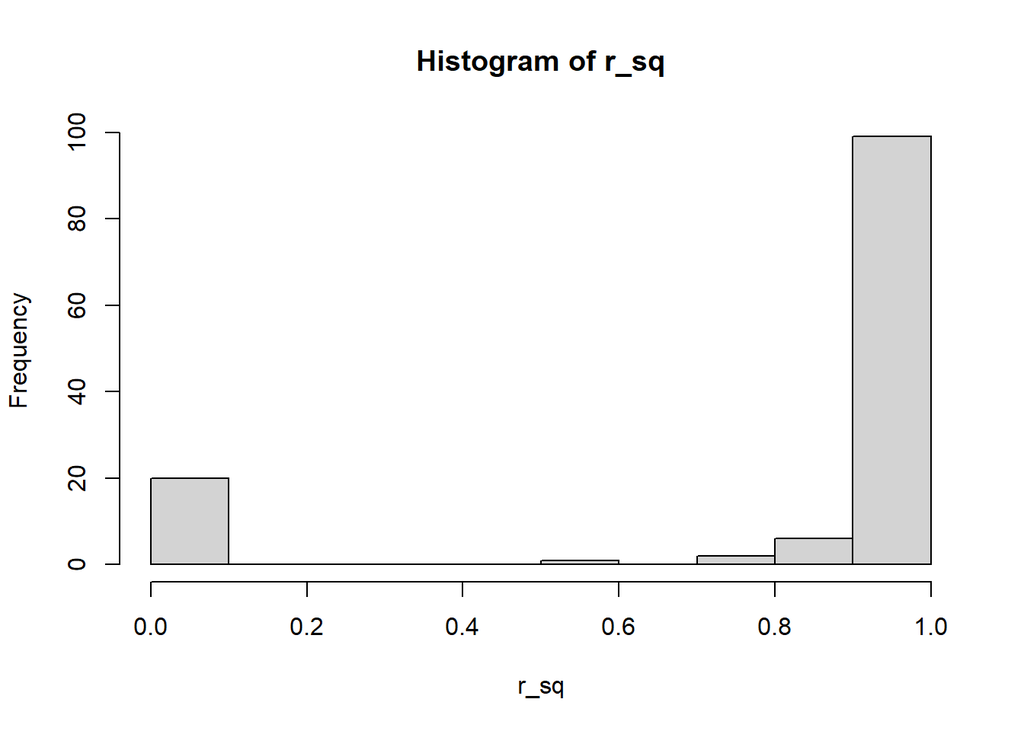

```r
# check the r-squared values
with(Dil_growthrates.df, hist(r_sq))
```

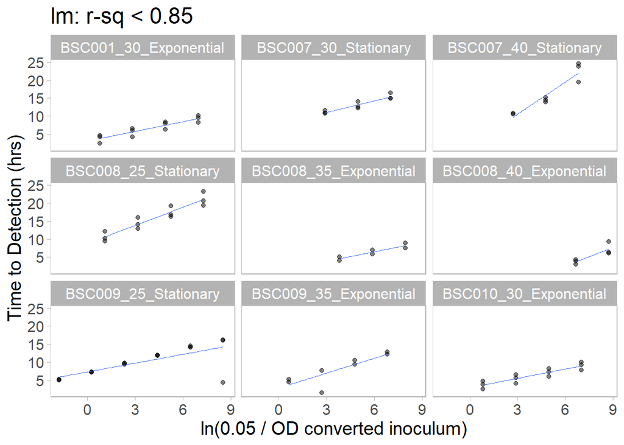

```r
# batch cultures that failed to grow reliably (need to have n=5 at minimum, corresponding with growth in at least 28% or 42% of incoulated wells) have 0 values for slope and r-squared.

# plot just the linear regressions that had low r-squared (there are 9 of them in total)
temp.low_rsq <- Dil_growthrates.df %>% filter(r_sq < 0.9) %>% filter(r_sq > 0) %>% select(Sample, Temp, Inoculum)
temp.low_rsq <- inner_join(temp.low_rsq, TTD.df) %>%
                  unite("sam_temp_inoc", c(Sample, Temp, Inoculum), remove=FALSE)
  # plot
ggplot(temp.low_rsq,
       aes(x=ln_Ntsmall_over_N0, y=TTD_0.05)) +
        facet_wrap(vars(sam_temp_inoc)) +
        geom_point(alpha=0.5) +
        geom_smooth(se=FALSE, method="lm", size=0.2) +
        labs(title="lm: r-sq < 0.85",
             x="ln(0.05 / OD converted inoculum)",
             y="Time to Detection (hrs)")
```

```r
# unfortunately, the r-squared is not a robust statistic of which linear regressions look unacceptable...

# clean up
rm(temp_CFUsurviv, CFUraw_inocula, inoc_data, inoc, sam, t, temp.low_rsq)
```

I removed all growth curves whose inoculated population size (by CFU estimates) was less than 20 cells. This is because low inocula will lead to very stochastic time-to-detection values, and we aren’t interested in that.

To get the 95% CI on the slope, I bootstrapped the data. Therefore I’m not very worried if there’s a weird outlier at the far end of the linear regression. This will ofc impact the mean estimate for the slope, but should be very robust to the CI.

## Plot & Analyze

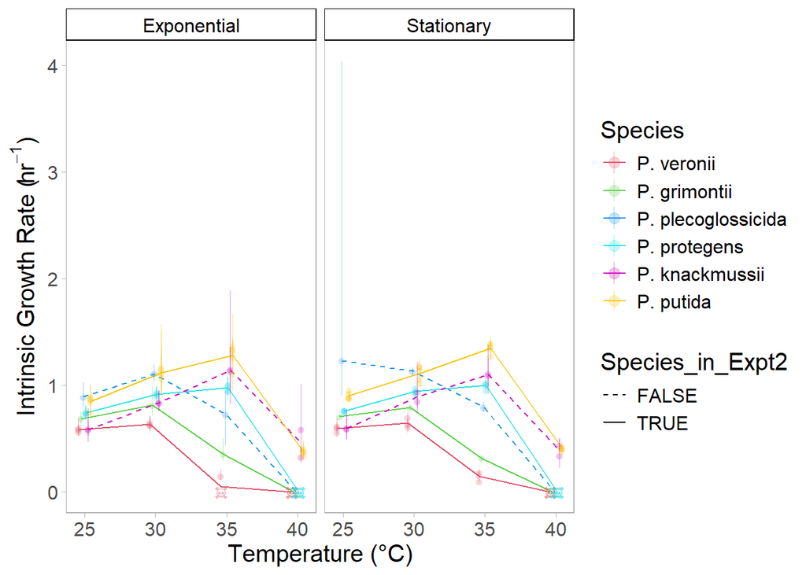

```r
# re-order the Species for appropriate colour plotting
Dil_growthrates.df$Species <- factor(Dil_growthrates.df$Species,
                                     levels=c("P. veronii", "P. grimontii", "P. plecoglossicida", "P. protegens", "P. knackmussii", "P. putida"))

# for plotting little skulls to emphasize lack of growth
Dil_growthrates.df$Shape <- ifelse(Dil_growthrates.df$mu==0, "\u2620", "\u25cf")
# re-organize the data.frame for correct plotting of shapes
Dil_growthrates.df <- Dil_growthrates.df %>% arrange(Inoculum, Species, Temp)

# plot all the data together
ggplot(Dil_growthrates.df,
       aes(x=Temp, y=mu, colour=Species, group=Species, linetype=Species_in_Expt2)) +
  facet_grid(. ~ Inoculum) +
  # add a smoothed line to join the different temperatures
  #geom_line(aes(x=Temp), stat="smooth", method="loess") +
  stat_summary(fun.y=mean, geom="line", position=position_dodge(width=1)) +
  geom_point(alpha=0.25, na.rm=TRUE, position=position_dodge(width=1),
             shape=Dil_growthrates.df$Shape, size=3) +
  geom_linerange(aes(ymin=mu_lwrCI, ymax=mu_uprCI),
                 alpha=0.25, na.rm=TRUE, position=position_dodge(width=1),
                 linetype="solid") +
  scale_colour_manual(values=ALLsp_palette) +
  scale_linetype_manual(values=c("dashed", "solid"))+
  labs(x=paste0("Temperature (", "\u00B0", "C)"),
       y=expression(paste("Intrinsic Growth Rate (", hr^{-1},")"))
       ) +
  theme(strip.background = element_rect(fill = "white", colour="black"),
        strip.text = element_text(color = "black"))
```

```r
print("Exponential phase culture data below:")
```

```
## [1] "Exponential phase culture data below:"
```

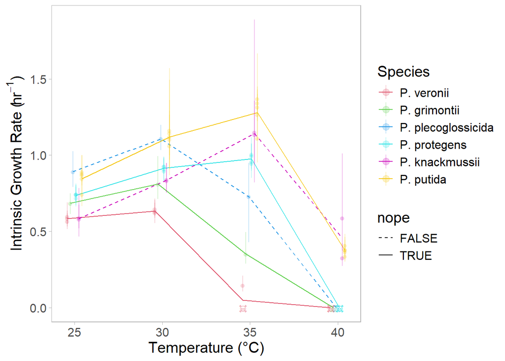

```r
# plot the exponential data only
muEXP.df <- Dil_growthrates.df %>% filter(Inoculum == "Exponential")
ggplot(muEXP.df,
       aes(x=Temp, y=mu, colour=Species, group=Species, linetype=Species_in_Expt2)) +
  # do NOT smooth the line used to join species across temperatures
  stat_summary(fun.y=mean, geom="line", position=position_dodge(width=1)) +
  geom_point(alpha=0.25, na.rm=TRUE, position=position_dodge(width = 1),
             shape=muEXP.df$Shape, size=3) +
  geom_linerange(aes(ymin=mu_lwrCI, ymax=mu_uprCI),
                 alpha=0.25, na.rm=TRUE, position=position_dodge(width = 1),
                 linetype="solid") +
  scale_colour_manual(values=ALLsp_palette) +
  scale_linetype_manual(values=c("dashed", "solid"))+
  labs(x=paste0("Temperature (", "\u00B0", "C)"),
       y=expression(paste("Intrinsic Growth Rate (", hr^{-1},")")),
       linetype = "nope"
       )
```

```r
# high quality figure for manuscript main text
png(filename="Fig2_A.png", width = 8.52, height = 4.4, units = "in", res=300)
ggplot(muEXP.df,
       aes(x=Temp, y=mu, colour=Species, group=Species, linetype=Species_in_Expt2)) +
  # do NOT smooth the line used to join species across temperatures
  stat_summary(fun.y=mean, geom="line", position=position_dodge(width=1.5)) +
  geom_point(alpha=0.25, na.rm=TRUE, position=position_dodge(width = 1.5),
             shape=muEXP.df$Shape, size=3) +
  geom_linerange(aes(ymin=mu_lwrCI, ymax=mu_uprCI),
                 alpha=0.25, na.rm=TRUE, position=position_dodge(width = 1.5),
                 linetype="solid") +
  scale_colour_manual(values=ALLsp_palette) +
  scale_linetype_manual(values=c("dashed", "solid"))+
  labs(x=paste0("Temperature (", "\u00B0", "C)"),
       y=expression(paste("Intrinsic Growth Rate ± 95% CI (", hr^{-1},")")),
       linetype = "Growth")
  # note that custom unicode shapes are very difficult to render in the legend
  # because R has poor font support.
  # see here: https://stackoverflow.com/questions/54870912/ggplot-shape-unicode-e-g-arrows-like-u2198-or-latex-searrow
dev.off()
```

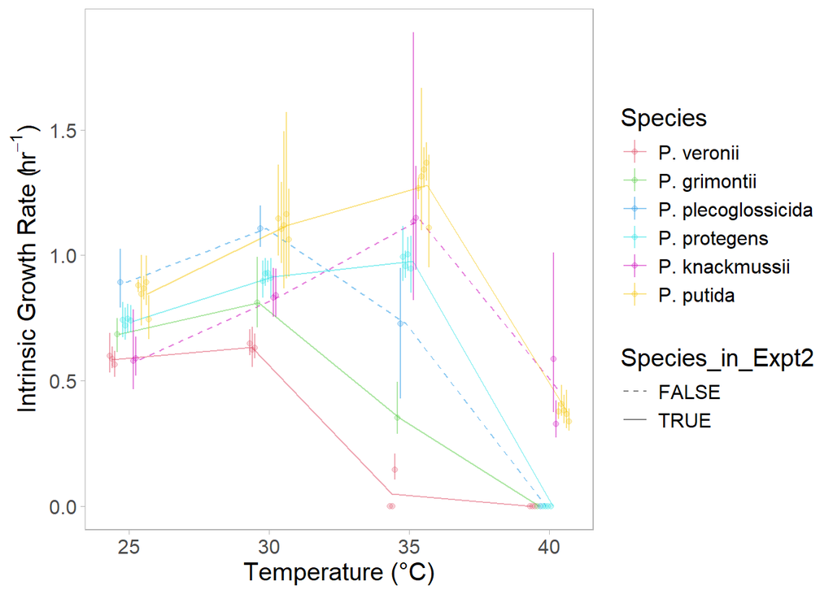

```r
# I SHOULD BE USING position_dodge2 TO SHOW ALL THE POINTS,
# but when I do that, the skulls end up in the wrong place
# on the other hand, there are no non-zero small values so maybe we can forget about the shape
ggplot(muEXP.df,
       aes(x=Temp, y=mu, colour=Species, group=Species, linetype=Species_in_Expt2)) +
  # do NOT smooth the line used to join species across temperatures
  stat_summary(alpha=0.5, fun.y=mean, geom="line", position=position_dodge2(width = 1.5)) +
  geom_point(alpha=0.25, na.rm=TRUE, position=position_dodge2(width = 1.5)) +
  geom_linerange(aes(ymin=mu_lwrCI, ymax=mu_uprCI),
                 alpha=0.5, na.rm=TRUE, position=position_dodge2(width = 1.5),
                 linetype="solid") +
  scale_colour_manual(values=ALLsp_palette) +
  scale_linetype_manual(values=c("dashed", "solid"))+
  labs(x=paste0("Temperature (", "\u00B0", "C)"),
       y=expression(paste("Intrinsic Growth Rate (", hr^{-1},")"))
       )
```

```r
# plot the stationary data only
print("Stationary phase culture data below:")
```

```
## [1] "Stationary phase culture data below:"
```

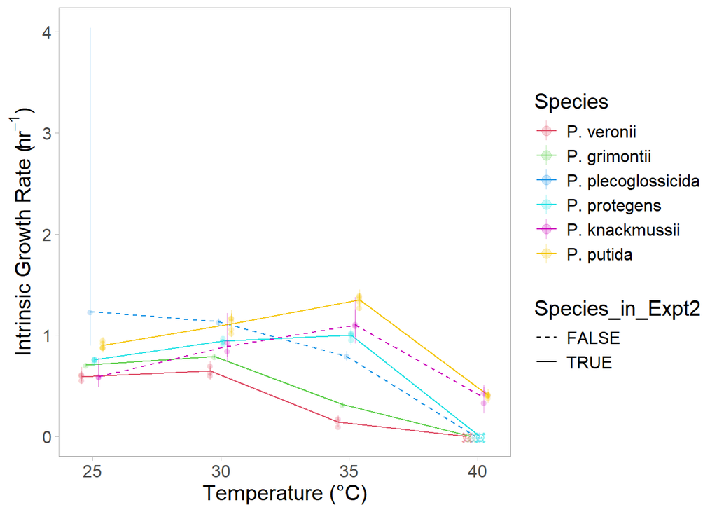

```r
muSTA.df <- Dil_growthrates.df %>% filter(Inoculum == "Stationary")
ggplot(muSTA.df,
       aes(x=Temp, y=mu, colour=Species, group=Species, linetype=Species_in_Expt2)) +
  # do NOT smooth the line used to join species across temperatures
  stat_summary(fun.y=mean, geom="line", position=position_dodge(width=1)) +
  geom_point(alpha=0.25, na.rm=TRUE, position=position_dodge(width = 1),
             shape=muSTA.df$Shape, size=3) +
  geom_linerange(aes(ymin=mu_lwrCI, ymax=mu_uprCI),
                 alpha=0.25, na.rm=TRUE, position=position_dodge(width = 1),
                 linetype="solid") +
  scale_colour_manual(values=ALLsp_palette) +
  scale_linetype_manual(values=c("dashed", "solid"))+
  labs(x=paste0("Temperature (", "\u00B0", "C)"),
       y=expression(paste("Intrinsic Growth Rate (", hr^{-1},")"))
       )
```

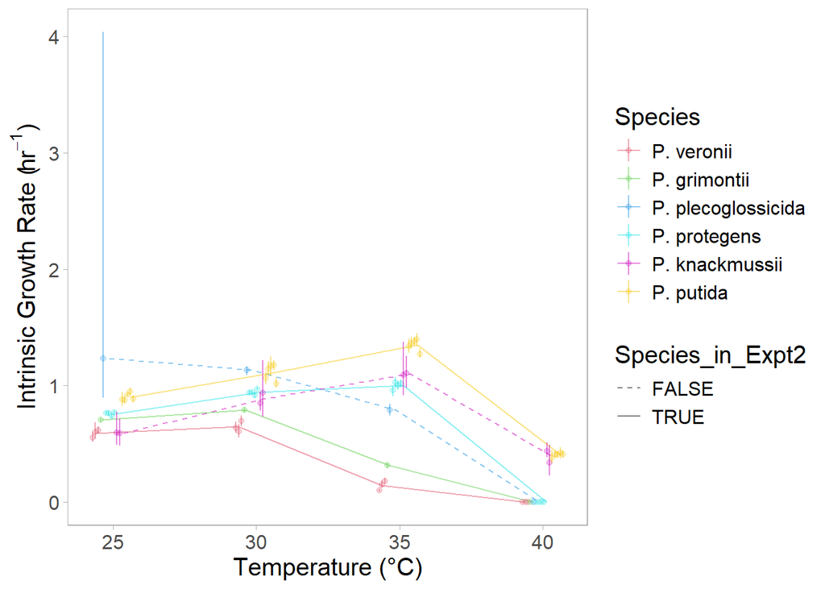

```r
# and plotted again with position_dodge2
ggplot(muSTA.df,
       aes(x=Temp, y=mu, colour=Species, group=Species, linetype=Species_in_Expt2)) +
  # do NOT smooth the line used to join species across temperatures
  stat_summary(alpha=0.5, fun.y=mean, geom="line", position=position_dodge2(width = 1.5)) +
  geom_point(alpha=0.25, na.rm=TRUE, position=position_dodge2(width = 1.5)) +
  geom_linerange(aes(ymin=mu_lwrCI, ymax=mu_uprCI),
                 alpha=0.5, na.rm=TRUE, position=position_dodge2(width = 1.5),
                 linetype="solid") +
  scale_colour_manual(values=ALLsp_palette) +
  scale_linetype_manual(values=c("dashed", "solid"))+
  labs(x=paste0("Temperature (", "\u00B0", "C)"),
       y=expression(paste("Intrinsic Growth Rate (", hr^{-1},")"))
       )
```

```r
rm(muSTA.df, muEXP.df)
```

### Statistical test of species rank orders

We can test whether the species’ rank orders remain the same across temperatures. We can do this for all 6 species across all 4 temperatures (using the Kendall’s Coefficient of Concordance). This would test the null hypothesis that bacterial species cannot be separated into fast VS slow growers. Alternative hypothesis: growth rate ranking is correlated across temperatures.

```r
# get the species rank by finding the median mu of each species
median_mu.df <- Dil_growthrates.df %>% group_by(Inoculum, Species, Temp) %>%
              summarise(medMu = median(mu))
# first try for exponential phase:

# test for overall fast vs slow growth strategy across all 4 temperatures
exp_rank.df <- median_mu.df %>% filter(Inoculum == "Exponential") %>%
                pivot_wider(names_from = Temp, values_from = medMu)
KendallW(exp_rank.df[,-1*(1:2)], correct = TRUE, test = TRUE)
```

```
##
##  Kendall's coefficient of concordance W (with ties correction)
##
## data:  exp_rank.df[, -1 * (1:2)]
## Kendall chi-squared = 11.385, df = 5, subjects = 6, raters = 4, p-value
## = 0.04427
## alternative hypothesis: W is greater 0
## sample estimates:
##         W
## 0.5692308
```

```r
# and for stationary phase

# test for overall fast vs slow growth strategy across all 4 temperatures
sta_rank.df <- median_mu.df %>% filter(Inoculum == "Stationary") %>%
                pivot_wider(names_from = Temp, values_from = medMu)
KendallW(sta_rank.df[,-1*(1:2)], correct = TRUE, test = TRUE)
```

```
##
##  Kendall's coefficient of concordance W (with ties correction)
##
## data:  sta_rank.df[, -1 * (1:2)]
## Kendall chi-squared = 12.615, df = 5, subjects = 6, raters = 4, p-value
## = 0.02726
## alternative hypothesis: W is greater 0
## sample estimates:
##         W
## 0.6307692
```

```r
# the thing is that we are not interested in exponential or stationary phase *PER SE*
# we are using these different cell physiologies as a way to make our results more generalizable
# so let's average across these different phases:
mean_median_mu.df <- median_mu.df %>% ungroup() %>% group_by(Species, Temp) %>%
                          summarise(mu_acrossInoc = mean(medMu))
ranks_acrossInoc.df <- mean_median_mu.df %>% pivot_wider(names_from = Temp, values_from = mu_acrossInoc)
KendallW(ranks_acrossInoc.df[,-1*(1:2)], correct = TRUE, test = TRUE)
```

```
##
##  Kendall's coefficient of concordance W (with ties correction)
##
## data:  ranks_acrossInoc.df[, -1 * (1:2)]
## Kendall chi-squared = 11.211, df = 5, subjects = 6, raters = 3, p-value
## = 0.04736
## alternative hypothesis: W is greater 0
## sample estimates:
##         W
## 0.7473684
```

```r
# clean up
rm(median_mu.df, mean_median_mu.df)
```

Okay, so there is a pretty good correlation in the species rankings across all the temperatures. For the complete set of all 6 species there is a significant positive correlation in the rankings across all 4 temperatures (both exponential and stationary inocula at p<0.05 by Kendall’s coefficient of concordance Wt). The Wt values are moderate (Wt=0.569 for exponential, Wt=0.631 for stationary).

This significance drops off when we remember the account for multiple testing by using Bonferonni-corrected $\alpha=0.05/2=0.025$ :(

On the other hand, we’re not actually interested in the effect of exponential or stationary phase *per se* – we’re using this as a way to make our results more generalizable. So looking at the overall rankings I think makes more sense. We also find that the p-value is bigger than for either the exponential or stationary phase data so that makes me feel this is conservative enough without being overly conservative …?

```r
################################
# consider the 4 SPECIES that do not change their rank order
################################
ranks_4species.df <- Dil_growthrates.df %>% filter(Species_in_Expt2 == TRUE) %>%
                      group_by(Inoculum, Species, Temp) %>%
                        summarise(medMu = median(mu))
# first check exponential and stationary phase data separately:

# exponential phase:
exp4SP_rank.df <- ranks_4species.df %>% filter(Inoculum == "Exponential") %>%
                    pivot_wider(names_from = Temp, values_from = medMu)
KendallW(exp4SP_rank.df[,-1*(1:2)], correct = TRUE, test = TRUE)
```

```
##
##  Kendall's coefficient of concordance W (with ties correction)
##
## data:  exp4SP_rank.df[, -1 * (1:2)]
## Kendall chi-squared = 11, df = 3, subjects = 4, raters = 4, p-value =
## 0.01173
## alternative hypothesis: W is greater 0
## sample estimates:
##         W
## 0.9166667
```

```r
# stationary phase:
sta4SP_rank.df <- ranks_4species.df%>% filter(Inoculum == "Stationary") %>%
                    pivot_wider(names_from = Temp, values_from = medMu)
KendallW(sta4SP_rank.df[,-1*(1:2)], correct = TRUE, test = TRUE)
```

```
##
##  Kendall's coefficient of concordance W (with ties correction)
##
## data:  sta4SP_rank.df[, -1 * (1:2)]
## Kendall chi-squared = 11, df = 3, subjects = 4, raters = 4, p-value =
## 0.01173
## alternative hypothesis: W is greater 0
## sample estimates:
##         W
## 0.9166667
```

```r
# finally check the combined data for both inocula
mean_median_mu.df <- ranks_4species.df %>% ungroup() %>% group_by(Species, Temp) %>%
                          summarise(mu_acrossInoc = mean(medMu))
acrossInoc_4SP_rank <- mean_median_mu.df %>% pivot_wider(names_from = Temp, values_from = mu_acrossInoc)
KendallW(acrossInoc_4SP_rank[,-1*(1:2)], correct = TRUE, test = TRUE)
```

```
##
##  Kendall's coefficient of concordance W (with ties correction)
##
## data:  acrossInoc_4SP_rank[, -1 * (1:2)]
## Kendall chi-squared = 8.0769, df = 3, subjects = 4, raters = 3, p-value
## = 0.04445
## alternative hypothesis: W is greater 0
## sample estimates:
##         W
## 0.8974359
```

```r
################################
# just the exact 4 STRAINS used in Expt 2
################################
ranks_4strains.df <- Dil_growthrates.df %>% select(Sample, Temp, Inoculum, mu) %>%
                      filter(Sample %in% c("BSC001", "CK101", "BSC019", "BSC005"))

# first check exponential and stationary phase data separately:

# exponential phase:
exp4STR_rank.df <- ranks_4strains.df %>% filter(Inoculum == "Exponential") %>%
                    pivot_wider(names_from = Temp, values_from = mu)
KendallW(exp4STR_rank.df[,-1*(1:2)], correct = TRUE, test = TRUE)
```

```
##
##  Kendall's coefficient of concordance W (with ties correction)
##
## data:  exp4STR_rank.df[, -1 * (1:2)]
## Kendall chi-squared = 11, df = 3, subjects = 4, raters = 4, p-value =
## 0.01173
## alternative hypothesis: W is greater 0
## sample estimates:
##         W
## 0.9166667
```

```r
# stationary phase:
sta4STR_rank.df <- ranks_4strains.df %>% filter(Inoculum == "Stationary") %>%
                    pivot_wider(names_from = Temp, values_from = mu)
KendallW(sta4STR_rank.df[,-1*(1:2)], correct = TRUE, test = TRUE)
```

```
##
##  Kendall's coefficient of concordance W (with ties correction)
##
## data:  sta4STR_rank.df[, -1 * (1:2)]
## Kendall chi-squared = 11, df = 3, subjects = 4, raters = 4, p-value =
## 0.01173
## alternative hypothesis: W is greater 0
## sample estimates:
##         W
## 0.9166667
```

```r
# finally check the combined data for both inocula
mean_median_mu.df <- ranks_4strains.df %>% ungroup() %>% group_by(Sample, Temp) %>%
                          summarise(mu_acrossInoc = mean(mu))
acrossInoc_4STR_rank <- mean_median_mu.df %>% pivot_wider(names_from = Temp, values_from = mu_acrossInoc)
KendallW(acrossInoc_4STR_rank[,-1*(1:2)], correct = TRUE, test = TRUE)
```

```
##
##  Kendall's coefficient of concordance W (with ties correction)
##
## data:  acrossInoc_4STR_rank[, -1 * (1:2)]
## Kendall chi-squared = 8.0769, df = 3, subjects = 4, raters = 3, p-value
## = 0.04445
## alternative hypothesis: W is greater 0
## sample estimates:
##         W
## 0.8974359
```

```r
# clean up
rm(ranks_4strains.df, mean_median_mu.df, ranks_4species.df)
```

If we consider the sub-set of 4 species used in Expt2, then the Wt values go up (Wt=0.917 for both exponential and stationary). Also the p-values have become small enough to slide under the Bonferonni-corrected $\alpha$’s :)

I also double-checked that the specific strains used in Expt2 are in agreement with the overall species means (just in case!). The results are indeed consistent.

### Correlation between species growth rate & its heat resistance

We can use a non-parametric approach using Spearman’s Rank Correlation Coefficient. This tests the null hypothesis that a species ranking at “ambient” temperature (e.g., 25C or 30C) is not correlated with its ranking at extreme heat (40C). Alternative hypothesis: growth rate ranking at ambient temperature is (positively or negatively) correlated with growth under extreme heat.

```r
# first, exponential phase:
cor.test(exp_rank.df$`25`, exp_rank.df$`40`, method = "spearman")
```

```
##
##  Spearman's rank correlation rho
##
## data:  exp_rank.df$`25` and exp_rank.df$`40`
## S = 46.832, p-value = 0.5122
## alternative hypothesis: true rho is not equal to 0
## sample estimates:
##        rho
## -0.3380617
```

```r
cor.test(exp_rank.df$`30`, exp_rank.df$`40`, method = "spearman")
```

```
##
##  Spearman's rank correlation rho
##
## data:  exp_rank.df$`30` and exp_rank.df$`40`
## S = 24.351, p-value = 0.5577
## alternative hypothesis: true rho is not equal to 0
## sample estimates:
##       rho
## 0.3042555
```

```r
# then for stationary phase
cor.test(sta_rank.df$`25`, sta_rank.df$`40`, method = "spearman")
```

```
##
##  Spearman's rank correlation rho
##
## data:  sta_rank.df$`25` and sta_rank.df$`40`
## S = 37.366, p-value = 0.8987
## alternative hypothesis: true rho is not equal to 0
## sample estimates:
##         rho
## -0.06761234
```

```r
cor.test(sta_rank.df$`30`, sta_rank.df$`40`, method = "spearman")
```

```
##
##  Spearman's rank correlation rho
##
## data:  sta_rank.df$`30` and sta_rank.df$`40`
## S = 17.252, p-value = 0.3046
## alternative hypothesis: true rho is not equal to 0
## sample estimates:
##       rho
## 0.5070926
```

```r
# finally try also for the combined data of exponential & stationary phase
cor.test(ranks_acrossInoc.df$`25`, ranks_acrossInoc.df$`40`, method = "spearman")
```

```
##
##  Spearman's rank correlation rho
##
## data:  ranks_acrossInoc.df$`25` and ranks_acrossInoc.df$`40`
## S = 46.832, p-value = 0.5122
## alternative hypothesis: true rho is not equal to 0
## sample estimates:
##        rho
## -0.3380617
```

```r
cor.test(ranks_acrossInoc.df$`30`, ranks_acrossInoc.df$`40`, method = "spearman")
```

```
##
##  Spearman's rank correlation rho
##
## data:  ranks_acrossInoc.df$`30` and ranks_acrossInoc.df$`40`
## S = 24.351, p-value = 0.5577
## alternative hypothesis: true rho is not equal to 0
## sample estimates:
##       rho
## 0.3042555
```

```r
# use Spearman’s Rank Correlation Coefficient to test for correlation between ambient and extreme
################################
# consider the 4 SPECIES that do not change their rank order
################################
# first, exponential phase:
cor.test(exp4SP_rank.df$`25`, exp4SP_rank.df$`40`, method = "spearman")
```

```
##
##  Spearman's rank correlation rho
##
## data:  exp4SP_rank.df$`25` and exp4SP_rank.df$`40`
## S = 2.254, p-value = 0.2254
## alternative hypothesis: true rho is not equal to 0
## sample estimates:
##       rho
## 0.7745967
```

```r
cor.test(exp4SP_rank.df$`30`, exp4SP_rank.df$`40`, method = "spearman")
```

```
##
##  Spearman's rank correlation rho
##
## data:  exp4SP_rank.df$`30` and exp4SP_rank.df$`40`
## S = 2.254, p-value = 0.2254
## alternative hypothesis: true rho is not equal to 0
## sample estimates:
##       rho
## 0.7745967
```

```r
# then stationary phase
cor.test(sta4SP_rank.df$`25`, sta4SP_rank.df$`40`, method = "spearman")
```

```
##
##  Spearman's rank correlation rho
##
## data:  sta4SP_rank.df$`25` and sta4SP_rank.df$`40`
## S = 2.254, p-value = 0.2254
## alternative hypothesis: true rho is not equal to 0
## sample estimates:
##       rho
## 0.7745967
```

```r
cor.test(sta4SP_rank.df$`30`, sta4SP_rank.df$`40`, method = "spearman")
```

```
##
##  Spearman's rank correlation rho
##
## data:  sta4SP_rank.df$`30` and sta4SP_rank.df$`40`
## S = 2.254, p-value = 0.2254
## alternative hypothesis: true rho is not equal to 0
## sample estimates:
##       rho
## 0.7745967
```

```r
# finally check the combined data for both inocula
cor.test(acrossInoc_4SP_rank$`25`, acrossInoc_4SP_rank$`40`, method = "spearman")
```

```
##
##  Spearman's rank correlation rho
##
## data:  acrossInoc_4SP_rank$`25` and acrossInoc_4SP_rank$`40`
## S = 2.254, p-value = 0.2254
## alternative hypothesis: true rho is not equal to 0
## sample estimates:
##       rho
## 0.7745967
```

```r
cor.test(acrossInoc_4SP_rank$`30`, acrossInoc_4SP_rank$`40`, method = "spearman")
```

```
##
##  Spearman's rank correlation rho
##
## data:  acrossInoc_4SP_rank$`30` and acrossInoc_4SP_rank$`40`
## S = 2.254, p-value = 0.2254
## alternative hypothesis: true rho is not equal to 0
## sample estimates:
##       rho
## 0.7745967
```

```r
################################
# try the exact 4 STRAINS used in Expt 2
################################
# first, exponential phase:
cor.test(exp4STR_rank.df$`25`, exp4STR_rank.df$`40`, method = "spearman")
```

```
##
##  Spearman's rank correlation rho
##
## data:  exp4STR_rank.df$`25` and exp4STR_rank.df$`40`
## S = 2.254, p-value = 0.2254
## alternative hypothesis: true rho is not equal to 0
## sample estimates:
##       rho
## 0.7745967
```

```r
cor.test(exp4STR_rank.df$`30`, exp4STR_rank.df$`40`, method = "spearman")
```

```
##
##  Spearman's rank correlation rho
##
## data:  exp4STR_rank.df$`30` and exp4STR_rank.df$`40`
## S = 2.254, p-value = 0.2254
## alternative hypothesis: true rho is not equal to 0
## sample estimates:
##       rho
## 0.7745967
```

```r
# then stationary phase
cor.test(sta4STR_rank.df$`25`, sta4STR_rank.df$`40`, method = "spearman")
```

```
##
##  Spearman's rank correlation rho
##
## data:  sta4STR_rank.df$`25` and sta4STR_rank.df$`40`
## S = 2.254, p-value = 0.2254
## alternative hypothesis: true rho is not equal to 0
## sample estimates:
##       rho
## 0.7745967
```

```r
cor.test(sta4STR_rank.df$`30`, sta4STR_rank.df$`40`, method = "spearman")
```

```
##
##  Spearman's rank correlation rho
##
## data:  sta4STR_rank.df$`30` and sta4STR_rank.df$`40`
## S = 2.254, p-value = 0.2254
## alternative hypothesis: true rho is not equal to 0
## sample estimates:
##       rho
## 0.7745967
```

```r
# finally check the combined data for both inocula
cor.test(acrossInoc_4STR_rank$`25`, acrossInoc_4STR_rank$`40`, method = "spearman")
```

```
##
##  Spearman's rank correlation rho
##
## data:  acrossInoc_4STR_rank$`25` and acrossInoc_4STR_rank$`40`
## S = 2.254, p-value = 0.2254
## alternative hypothesis: true rho is not equal to 0
## sample estimates:
##       rho
## 0.7745967
```

```r
cor.test(acrossInoc_4STR_rank$`30`, acrossInoc_4STR_rank$`40`, method = "spearman")
```

```
##
##  Spearman's rank correlation rho
##
## data:  acrossInoc_4STR_rank$`30` and acrossInoc_4STR_rank$`40`
## S = 2.254, p-value = 0.2254
## alternative hypothesis: true rho is not equal to 0
## sample estimates:
##       rho
## 0.7745967
```

```r
# clean up
rm(exp_rank.df, exp4STR_rank.df, exp4SP_rank.df, sta_rank.df, sta4SP_rank.df, sta4STR_rank.df, acrossInoc_4SP_rank, acrossInoc_4STR_rank, ranks_acrossInoc.df)
```

Here we see no significant effects for either all 6 species (p $\approx$ 0.5) or the subset of 4 species (p $\approx$ 0.2). The rho value is smaller for all 6 species and suggestively larger for the subset of 4 species… But definitely not significant, especially when we take into account that the Bonferroni-corrected $\alpha$’s should be something like $0.05/4=0.0125$.

Maybe using a parametric approach can help us squeeze a bit more power out of our data???

```r
resist_mu <- Dil_growthrates.df %>% select(Sample, Species, Temp, Inoculum, mu) %>%
                pivot_wider(names_from = Temp, names_prefix="mu_Temp", values_from = mu)

####################
# mu at 25C predicting mu at 40C
####################

# fit a linear model where mu at 25C predicts mu at 40C but with random effect of species ... (if we're here anyway, test if Inoculum has any effect)
tmpLM0_mu_25 <- glmmTMB(mu_Temp40 ~ mu_Temp25, # fixed effect only
                        data = resist_mu)
tmpLMM0_mu <- glmmTMB(mu_Temp40 ~ (1|Species), # random effect NULL MODEL!!!
                        data = resist_mu)
tmpLMM_mu_25 <- glmmTMB(mu_Temp40 ~ mu_Temp25 + (1|Species),
                        data = resist_mu)
tmpLMM2_mu_25 <- glmmTMB(mu_Temp40 ~ mu_Temp25 + (1|Inoculum),
                        data = resist_mu)
tmpLMM3_mu_25 <- glmmTMB(mu_Temp40 ~ mu_Temp25 + (1|Species) + (1|Inoculum),
                        data = resist_mu)
BIC(tmpLM0_mu_25, tmpLMM0_mu, tmpLMM_mu_25, tmpLMM2_mu_25, tmpLMM3_mu_25) %>% arrange(BIC)
```

|  | df | BIC |
| --- | --- | --- |
| tmpLMM0_mu | 3 | -72.307355 |
| tmpLMM_mu_25 | 4 | -69.077090 |
| tmpLMM3_mu_25 | 5 | -65.611354 |
| tmpLM0_mu_25 | 3 | -2.542514 |
| tmpLMM2_mu_25 | 4 | 0.923222 |

```r
# the null model with random effect of species is the best model
anova(tmpLMM0_mu, tmpLMM_mu_25)
```

|  | Df | AIC | BIC | logLik | deviance | Chisq | Chi Df | Pr(>Chisq) |
| --- | --- | --- | --- | --- | --- | --- | --- | --- |
| tmpLMM0_mu | 3 | -76.70456 | -72.30736 | 41.35228 | -82.70456 | NA | NA | NA |
| tmpLMM_mu_25 | 4 | -74.94003 | -69.07709 | 41.47002 | -82.94003 | 0.2354709 | 1 | 0.6274966 |

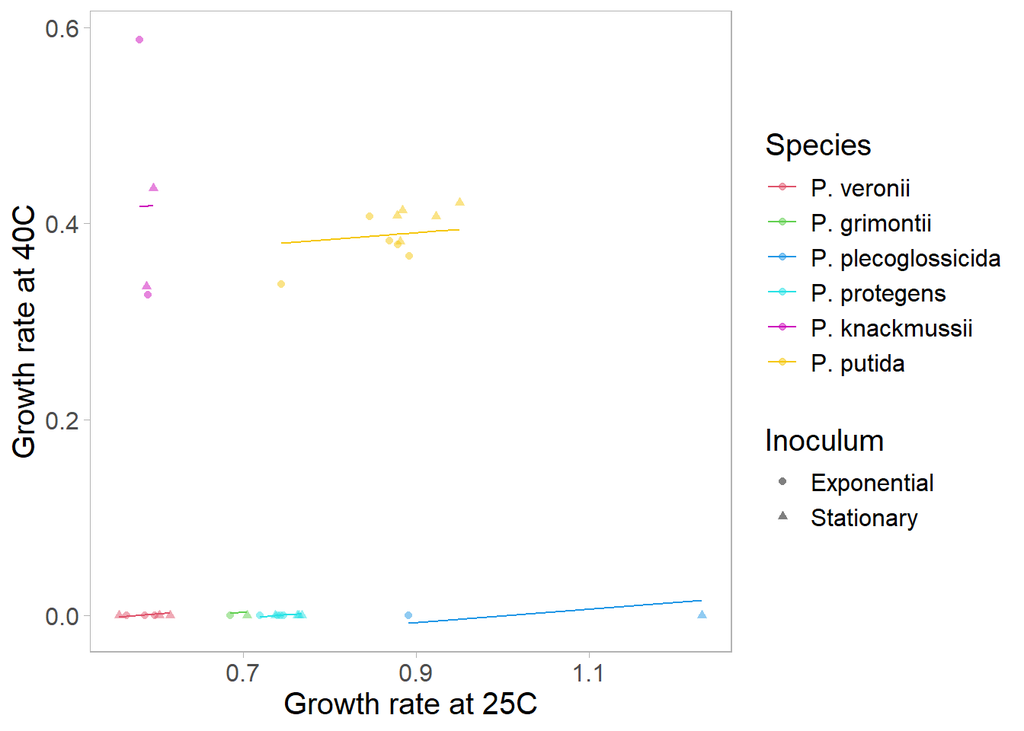

```r
rm(tmpLM0_mu_25, tmpLMM2_mu_25, tmpLMM3_mu_25)
# BUT we are NOT INTERESTED in the null model with only random effect of species!!!

# okay so it seems that my intuition was right that a model with random effect of species is best. Let's plot it & see it's effect sizes and explanatory power
tmp_resist_mu <- cbind(resist_mu,
                       predicted = predict(tmpLMM_mu_25, type="response"),
                       resid = residuals(tmpLMM_mu_25))
ggplot(tmp_resist_mu,
       aes(x=mu_Temp25, y=mu_Temp40, colour=Species, shape=Inoculum)) +
  geom_point(alpha=0.5) +
  geom_line(aes(y = predicted, group = Species)) +
  scale_colour_manual(values=ALLsp_palette) +
  labs(x="Growth rate at 25C", y="Growth rate at 40C")
```

```r
summary(tmpLMM_mu_25)
```

```
##  Family: gaussian  ( identity )
## Formula:          mu_Temp40 ~ mu_Temp25 + (1 | Species)
## Data: resist_mu
##
##       AIC       BIC    logLik -2*log(L)  df.resid
##     -74.9     -69.1      41.5     -82.9        28
##
## Random effects:
##
## Conditional model:
##  Groups   Name        Variance Std.Dev.
##  Species  (Intercept) 0.037045 0.19247
##  Residual             0.001893 0.04351
## Number of obs: 32, groups:  Species, 6
##
## Dispersion estimate for gaussian family (sigma^2): 0.00189
##
## Conditional model:
##             Estimate Std. Error z value Pr(>|z|)
## (Intercept)  0.08420    0.13253   0.635    0.525
## mu_Temp25    0.06821    0.14009   0.487    0.626
```

```r
emmeans(tmpLMM_mu_25, ~ mu_Temp25, type="response")
```

```
##  mu_Temp25 emmean     SE df lower.CL upper.CL
##      0.754  0.136 0.0791 28  -0.0265    0.298
##
## Confidence level used: 0.95
```

```r
efronRSquared(residual = tmp_resist_mu$resid,
              predicted = tmp_resist_mu$predicted,
              statistic = "EfronRSquared")
```

```
## EfronRSquared
##         0.962
```

```r
# hahhahhaha, I love this r-squared value! I guess the random effect of species is actually a great fit. We already saw this from the BIC model comparison above.
rm(tmpLMM_mu_25, tmp_resist_mu)

####################
# mu at 30C predicting mu at 40C
####################

# fit a linear model where mu at 30C predicts mu at 40C but with random effect of species ... (if we're here anyway, test if Inoculum has any effect)
tmpLM0_mu_30 <- glmmTMB(mu_Temp40 ~ mu_Temp30, # fixed effect only
                        data = resist_mu)
tmpLMM0_mu <- glmmTMB(mu_Temp40 ~ (1|Species), # random effect NULL MODEL!!!
                        data = resist_mu)
tmpLMM_mu_30 <- glmmTMB(mu_Temp40 ~ mu_Temp30 + (1|Species),
                        data = resist_mu)
tmpLMM2_mu_30 <- glmmTMB(mu_Temp40 ~ mu_Temp30 + (1|Inoculum),
                        data = resist_mu)
tmpLMM3_mu_30 <- glmmTMB(mu_Temp40 ~ mu_Temp30 + (1|Species) + (1|Inoculum),
                        data = resist_mu)
BIC(tmpLM0_mu_30, tmpLMM0_mu, tmpLMM_mu_30, tmpLMM2_mu_30, tmpLMM3_mu_30) %>% arrange(BIC)
```

|  | df | BIC |
| --- | --- | --- |
| tmpLMM0_mu | 3 | -72.307355 |
| tmpLMM_mu_30 | 4 | -69.024442 |
| tmpLMM3_mu_30 | 5 | -65.558706 |
| tmpLM0_mu_30 | 3 | -11.769851 |
| tmpLMM2_mu_30 | 4 | -8.304115 |

```r
# the null model with random effect of species is the best model
anova(tmpLMM0_mu, tmpLMM_mu_30)
```

|  | Df | AIC | BIC | logLik | deviance | Chisq | Chi Df | Pr(>Chisq) |
| --- | --- | --- | --- | --- | --- | --- | --- | --- |
| tmpLMM0_mu | 3 | -76.70456 | -72.30736 | 41.35228 | -82.70456 | NA | NA | NA |
| tmpLMM_mu_30 | 4 | -74.88739 | -69.02444 | 41.44369 | -82.88739 | 0.1828226 | 1 | 0.6689586 |

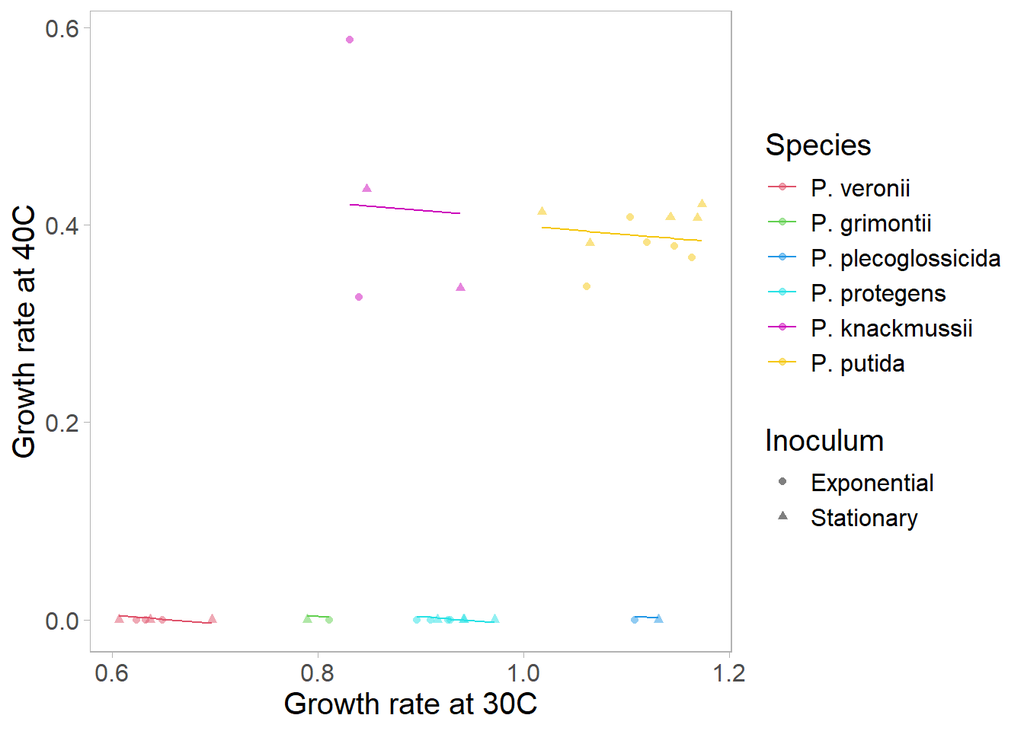

```r
rm(tmpLM0_mu_30, tmpLMM0_mu, tmpLMM2_mu_30, tmpLMM3_mu_30)
# BUT we are NOT INTERESTED in the null model with only random effect of species!!!

# again my intuition was right. Let's plot & analyze the model of interest
tmp_resist_mu <- cbind(resist_mu,
                       predicted = predict(tmpLMM_mu_30, type="response"),
                       resid = residuals(tmpLMM_mu_30))
ggplot(tmp_resist_mu,
       aes(x=mu_Temp30, y=mu_Temp40, colour=Species, shape=Inoculum)) +
  geom_point(alpha=0.5) +
  geom_line(aes(y = predicted, group = Species)) +
  scale_colour_manual(values=ALLsp_palette) +
  labs(x="Growth rate at 30C", y="Growth rate at 40C")
```

```r
summary(tmpLMM_mu_30)
```

```
##  Family: gaussian  ( identity )
## Formula:          mu_Temp40 ~ mu_Temp30 + (1 | Species)
## Data: resist_mu
##
##       AIC       BIC    logLik -2*log(L)  df.resid
##     -74.9     -69.0      41.4     -82.9        28
##
## Random effects:
##
## Conditional model:
##  Groups   Name        Variance Std.Dev.
##  Species  (Intercept) 0.038297 0.19570
##  Residual             0.001883 0.04339
## Number of obs: 32, groups:  Species, 6
##
## Dispersion estimate for gaussian family (sigma^2): 0.00188
##
## Conditional model:
##             Estimate Std. Error z value Pr(>|z|)
## (Intercept)  0.21393    0.19880   1.076    0.282
## mu_Temp30   -0.08558    0.19956  -0.429    0.668
```

```r
emmeans(tmpLMM_mu_30, ~ mu_Temp30, type="response")
```

```
##  mu_Temp30 emmean     SE df lower.CL upper.CL
##      0.929  0.134 0.0805 28  -0.0305    0.299
##
## Confidence level used: 0.95
```

```r
efronRSquared(residual = tmp_resist_mu$resid,
              predicted = tmp_resist_mu$predicted,
              statistic = "EfronRSquared")
```

```
## EfronRSquared
##         0.962
```

```r
# again, this great explanatory power is coming purely from the random effect of species
rm(tmpLMM_mu_30, tmp_resist_mu)


####################
# mu at 25C predicting relative CFU at 40C
####################

resist_CFU <- inner_join(resist_mu %>% select(-mu_Temp35, -mu_Temp40),
                         CFU_survival.df %>% filter(Temp == 40) %>% select(-Shape, -temp_as_factor),
                   by = c("Sample", "Species", "Inoculum"))

# fit a linear model where mu at 25C predicts relative CFU at 40C but with random effect of species ... (if we're here anyway, test if Inoculum has any effect)
tmpLM0_CFU_25 <- glmmTMB(mean_surviv ~ mu_Temp25, # fixed effect only
                        data = resist_CFU)
tmpLMM0_CFU <- glmmTMB(mean_surviv ~ (1|Species), # random effect NULL MODEL!!!
                        data = resist_CFU)
tmpLMM_CFU_25 <- glmmTMB(mean_surviv ~ mu_Temp25 + (1|Species),
                        data = resist_CFU)
tmpLMM2_CFU_25 <- glmmTMB(mean_surviv ~ mu_Temp25 + (1|Inoculum),
                        data = resist_CFU)
tmpLMM3_CFU_25 <- glmmTMB(mean_surviv ~ mu_Temp25 + (1|Species) + (1|Inoculum),
                        data = resist_CFU)
BIC(tmpLM0_CFU_25, tmpLMM0_CFU, tmpLMM_CFU_25, tmpLMM2_CFU_25, tmpLMM3_CFU_25) %>% arrange(BIC)
```

|  | df | BIC |
| --- | --- | --- |
| tmpLMM0_CFU | 3 | 21.84279 |
| tmpLMM_CFU_25 | 4 | 25.30540 |
| tmpLMM3_CFU_25 | 5 | 28.77058 |
| tmpLM0_CFU_25 | 3 | 50.96730 |
| tmpLMM2_CFU_25 | 4 | 54.43303 |

```r
# the null model with random effect of species is the best model
anova(tmpLMM0_CFU, tmpLMM_CFU_25)
```

|  | Df | AIC | BIC | logLik | deviance | Chisq | Chi Df | Pr(>Chisq) |
| --- | --- | --- | --- | --- | --- | --- | --- | --- |
| tmpLMM0_CFU | 3 | 17.44558 | 21.84279 | -5.722791 | 11.44558 | NA | NA | NA |
| tmpLMM_CFU_25 | 4 | 19.44246 | 25.30540 | -5.721228 | 11.44246 | 0.003125556 | 1 | 0.9554162 |

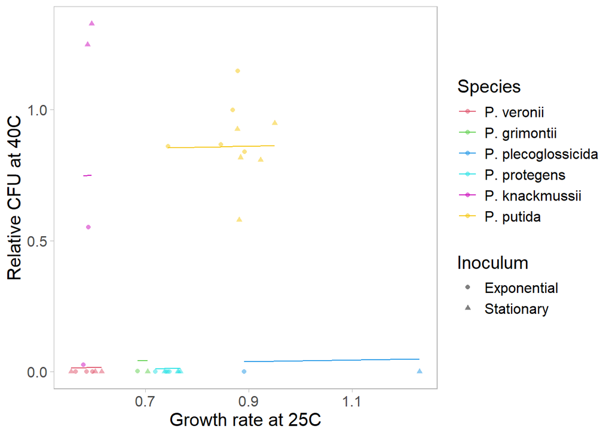

```r
rm(tmpLM0_CFU_25, tmpLMM2_CFU_25, tmpLMM3_CFU_25)
# BUT we are NOT INTERESTED in the null model with only random effect of species!!!

# again my intuition was right. Let's plot & analyze the model of interest
tmp_resist_CFU <- cbind(resist_CFU,
                       predicted = predict(tmpLMM_CFU_25, type="response"),
                       resid = residuals(tmpLMM_CFU_25))
ggplot(tmp_resist_CFU,
       aes(x=mu_Temp25, y=mean_surviv, colour=Species, shape=Inoculum)) +
  geom_point(alpha=0.5) +
  geom_line(aes(y = predicted, group = Species)) +
  scale_colour_manual(values=ALLsp_palette) +
  labs(x="Growth rate at 25C", y="Relative CFU at 40C")
```

```r
summary(tmpLMM_CFU_25)
```

```
##  Family: gaussian  ( identity )
## Formula:          mean_surviv ~ mu_Temp25 + (1 | Species)
## Data: resist_CFU
##
##       AIC       BIC    logLik -2*log(L)  df.resid
##      19.4      25.3      -5.7      11.4        28
##
## Random effects:
##
## Conditional model:
##  Groups   Name        Variance Std.Dev.
##  Species  (Intercept) 0.14752  0.3841
##  Residual             0.05101  0.2259
## Number of obs: 32, groups:  Species, 6
##
## Dispersion estimate for gaussian family (sigma^2): 0.051
##
## Conditional model:
##             Estimate Std. Error z value Pr(>|z|)
## (Intercept)  0.26146    0.48519   0.539    0.590
## mu_Temp25    0.03373    0.60348   0.056    0.955
```

```r
emmeans(tmpLMM_CFU_25, ~ mu_Temp25, type="response")
```

```
##  mu_Temp25 emmean    SE df lower.CL upper.CL
##      0.754  0.287 0.164 28  -0.0489    0.623
##
## Confidence level used: 0.95
```

```r
efronRSquared(residual = tmp_resist_CFU$resid,
              predicted = tmp_resist_CFU$predicted,
              statistic = "EfronRSquared")
```

```
## EfronRSquared
##         0.809
```

```r
# again, this high explanatory power is coming purely from the random effect of species
rm(tmpLMM_CFU_25, tmp_resist_CFU)



####################
# mu at 30C predicting relative CFU at 40C
####################

# fit a linear model where mu at 30C predicts relative CFU at 40C but with random effect of species ... (if we're here anyway, test if Inoculum has any effect)
tmpLM0_CFU_30 <- glmmTMB(mean_surviv ~ mu_Temp30, # fixed effect only
                        data = resist_CFU)
tmpLMM_CFU_30 <- glmmTMB(mean_surviv ~ mu_Temp30 + (1|Species),
                        data = resist_CFU)
tmpLMM2_CFU_30 <- glmmTMB(mean_surviv ~ mu_Temp30 + (1|Inoculum),
                        data = resist_CFU)
tmpLMM3_CFU_30 <- glmmTMB(mean_surviv ~ mu_Temp30 + (1|Species) + (1|Inoculum),
                        data = resist_CFU)
BIC(tmpLM0_CFU_30, tmpLMM0_CFU, tmpLMM_CFU_30, tmpLMM2_CFU_30, tmpLMM3_CFU_30) %>% arrange(BIC)
```

|  | df | BIC |
| --- | --- | --- |
| tmpLMM_CFU_30 | 4 | 21.37941 |
| tmpLMM0_CFU | 3 | 21.84279 |
| tmpLMM3_CFU_30 | 5 | 24.84515 |
| tmpLM0_CFU_30 | 3 | 40.47093 |
| tmpLMM2_CFU_30 | 4 | 43.93667 |

```r
# HA! finally the mixed model is at least as good as the null model!
anova(tmpLMM0_CFU, tmpLMM_CFU_30)
```

|  | Df | AIC | BIC | logLik | deviance | Chisq | Chi Df | Pr(>Chisq) |
| --- | --- | --- | --- | --- | --- | --- | --- | --- |
| tmpLMM0_CFU | 3 | 17.44558 | 21.84279 | -5.722791 | 11.445582 | NA | NA | NA |
| tmpLMM_CFU_30 | 4 | 15.51647 | 21.37941 | -3.758236 | 7.516471 | 3.929111 | 1 | 0.04745703 |

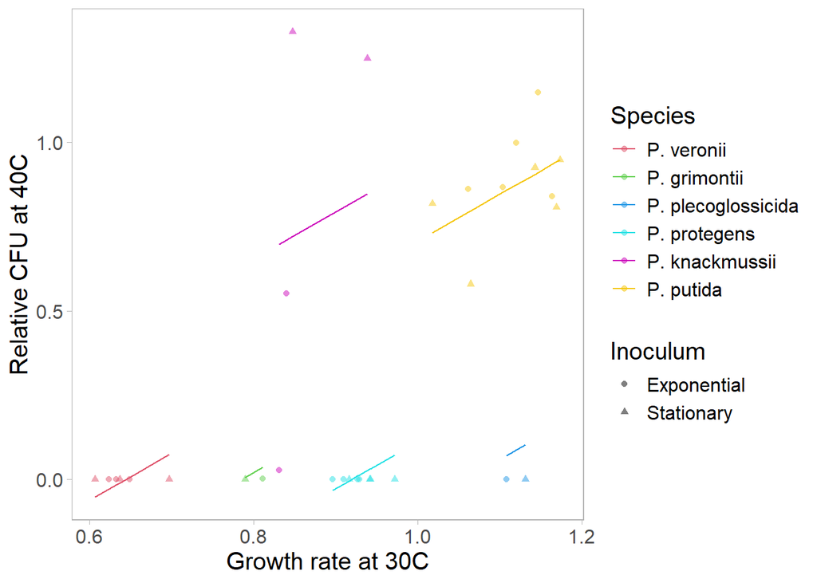

```r
rm(tmpLM0_CFU_30, tmpLMM2_CFU_30, tmpLMM3_CFU_30, tmpLMM0_CFU)
# great, now we are even justified to get rid of the null model :)

# Let's plot & analyze the top model
tmp_resist_CFU <- cbind(resist_CFU,
                       predicted = predict(tmpLMM_CFU_30, type="response"),
                       resid = residuals(tmpLMM_CFU_30))
ggplot(tmp_resist_CFU,
       aes(x=mu_Temp30, y=mean_surviv, colour=Species, shape=Inoculum)) +
  geom_point(alpha=0.5) +
  geom_line(aes(y = predicted, group = Species)) +
  scale_colour_manual(values=ALLsp_palette) +
  labs(x="Growth rate at 30C", y="Relative CFU at 40C")
```

```r
summary(tmpLMM_CFU_30)
```

```
##  Family: gaussian  ( identity )
## Formula:          mean_surviv ~ mu_Temp30 + (1 | Species)
## Data: resist_CFU
##
##       AIC       BIC    logLik -2*log(L)  df.resid
##      15.5      21.4      -3.8       7.5        28
##
## Random effects:
##
## Conditional model:
##  Groups   Name        Variance Std.Dev.
##  Species  (Intercept) 0.1294   0.3597
##  Residual             0.0452   0.2126
## Number of obs: 32, groups:  Species, 6
##
## Dispersion estimate for gaussian family (sigma^2): 0.0452
##
## Conditional model:
##             Estimate Std. Error z value Pr(>|z|)
## (Intercept)  -0.9810     0.6603  -1.486   0.1373
## mu_Temp30     1.3919     0.7032   1.980   0.0478 *
## ---
## Signif. codes:  0 '***' 0.001 '**' 0.01 '*' 0.05 '.' 0.1 ' ' 1
```

```r
# the trouble here is that the model is only very slightly significant and we probably need to correct for multiple testing...
emmeans(tmpLMM_CFU_30, ~ mu_Temp30, type="response")
```

```
##  mu_Temp30 emmean    SE df lower.CL upper.CL
##      0.929  0.312 0.154 28 -0.00313    0.628
##
## Confidence level used: 0.95
```

```r
# in fact, so slight that the effect size is not quite significant
efronRSquared(residual = tmp_resist_CFU$resid,
              predicted = tmp_resist_CFU$predicted,
              statistic = "EfronRSquared")
```

```
## EfronRSquared
##         0.831
```

```r
rm(tmpLMM_CFU_30, tmp_resist_CFU)
```

The growth rate at “ambient” temperatures (25C or 30C) does not predict the growth rate at extreme temperature (40C). Neither does it predict the relative CFUs at extreme temperature…

The effect size of growth rate at 30C is almost significant in predicting relative CFU at 40C. I say “almost” because we need to Bonferroni correct for multiple testing (e.g., of both 25C and 30C ambient temperatures but probably also for mu and relative CFU). This means that – at the very least – our Bonferroni-corrected $\alpha = 0.05/2$. So it’s not quite over that threshold.

Probably as the “ambient” temperature gets closer to the “extreme stress” temperature, there’s going to be better agreement in the data.

### Which hot temperture has lower mu?

Again we can use either a paired t-test or a two-sided Wilcoxon signed rank test to check that growth rates are indeed significantly lower at 40C for all species.

First let’s try the paired t-test because growth rates are continuous so, if they are also Normally distributed, then this will be more appropriate.

```r
growthrates_40vs35 <- Dil_growthrates.df %>% filter(Temp > 30) %>%
                        select(Sample, Temp, Inoculum, mu) %>%
                          pivot_wider(names_from = Temp,
                                      names_glue = "{.value}{Temp}",
                                      values_from = mu) %>%
                            mutate(diff = mu35 - mu40)

# check for normality using the shapiro-wilk test
shapiro.test(growthrates_40vs35$diff)
```

```
##
##  Shapiro-Wilk normality test
##
## data:  growthrates_40vs35$diff
## W = 0.79005, p-value = 2.665e-05
```

```r
# looks like the data is not normal... weeellll, the shapiro-wilk test is quite sensitive and a t-test should anyway be quite robust to violations from Normality...

# go ahead and run the paired t-test anyway
with(growthrates_40vs35, t.test(x = mu35, y = mu40, paired = TRUE))
```

```
##
##  Paired t-test
##
## data:  mu35 and mu40
## t = 11.526, df = 31, p-value = 9.719e-13
## alternative hypothesis: true mean difference is not equal to 0
## 95 percent confidence interval:
##  0.5841729 0.8353607
## sample estimates:
## mean difference
##       0.7097668
```

```r
# and for good measure, also run the two-sided Wilcoxon signed rank test
with(growthrates_40vs35, wilcox.test(x = mu35, y = mu40, paired = TRUE))
```

```
##
##  Wilcoxon signed rank test with continuity correction
##
## data:  mu35 and mu40
## V = 465, p-value = 1.825e-06
## alternative hypothesis: true location shift is not equal to 0
```

```r
# clean up
rm(growthrates_40vs35)
```

Rather predictably, our growth rates data at 35C and 40C failed the statistical test of Normality. I rationalized that the t-test should be quite robust to violations and I went ahead it ran it along with the non-parametric test. As expected, both are significant.

# Plot weird 40C growth by P. protegens

P. protegens showed density-dependent growth at 40C. Growth curves for all strains at all temperatures are given above but below is a plot of P. protegens Pf5 to go in the supplement

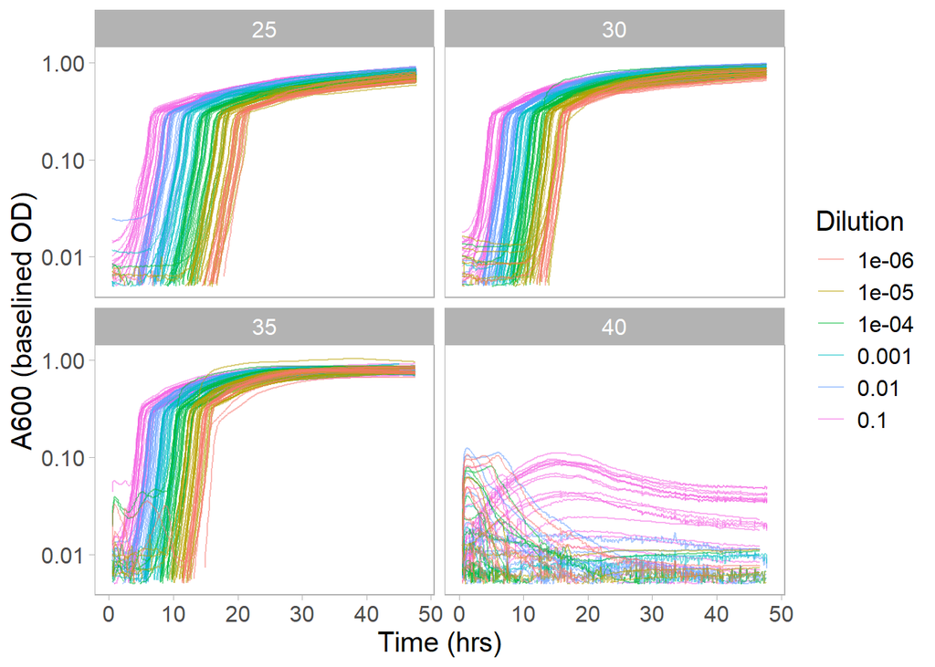

```r
# first let's smooth out the data (we will need to do this for estimating the derivatives anyway)
smoothed_ALL.df <- ALL_data.df %>% ungroup() %>%
                      mutate(smooth_med3 = smooth_data(x = Time,
                                                       y = OD,
                                                       subset_by = uniqID,
                                                       sm_method = "moving-median",
                                                       window_width_n = 3),
                             smoothOD = smooth_data(x = Time,
                                                    y = smooth_med3,
                                                    subset_by = uniqID,
                                                    sm_method = "moving-average",
                                                    window_width_n = 3))
smoothed_ALL.df <- smoothed_ALL.df %>% mutate(smth_baselinedOD = smoothOD - medianBlankOD)

# add the option to keep just the growth curves that were high quality enough to analyze for TTD
  # e.g., exclude growth curves that were inoculated with too few cells
smoothed_ALL.df$Dilution <- as.numeric(levels(smoothed_ALL.df$Dilution))[smoothed_ALL.df$Dilution] # temporarily change class for compatible joining
smoothed_ALL.df <- left_join(smoothed_ALL.df,
                             TTD.df %>% select(Temp, Sample, Dilution, Inoculum, uniqID, Species, TTD_0.05, TTD_0.13))
smoothed_ALL.df$Dilution <- as.factor(smoothed_ALL.df$Dilution) # change back to factor because it's more convenient for plotting

#########################
# plot P. protegens
#########################

temp_data_for_plotting <- rbind(smoothed_ALL.df %>%
                                    filter(Species == "P. protegens",
                                           !is.na(TTD_0.13)),
  # replicates at 40C were excluded from TTD so need to add them back in manually for plotting
                                smoothed_ALL.df %>%
                                    filter(Species == "P. protegens",
                                           Temp == 40))
ggplot(temp_data_for_plotting,
       aes(y = smth_baselinedOD, x = Time, colour = Dilution, group = uniqID)) +
  facet_wrap(vars(Temp)) +
  scale_y_log10(limits=c(0.005,1.1)) +
  geom_line(alpha=0.5) +
  labs(x="Time (hrs)", y="A600 (baselined OD)")
```

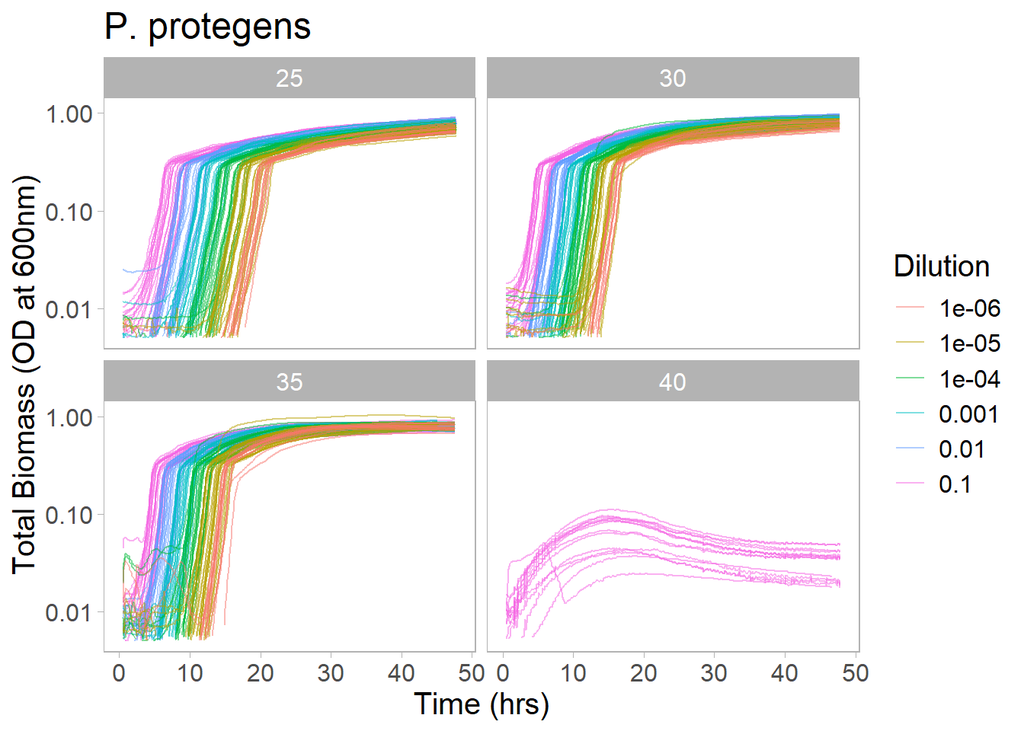

```r
# wells that failed to grow seemed to have had condensation early on
# this obscures the information we are trying to present so let's try to exclude all wells that failed to grow
temp <- temp_data_for_plotting %>% group_by(uniqID, Temp, Dilution, Sample) %>%
          summarise(medOD = median(smth_baselinedOD, na.rm=TRUE))
these_grew <- temp$uniqID[temp$medOD > 0.02]

ggplot(temp_data_for_plotting %>% filter(uniqID %in% these_grew),
       aes(y = smth_baselinedOD, x = Time, colour = Dilution, group = uniqID)) +
  facet_wrap(vars(Temp)) +
  scale_y_log10(limits=c(0.005,1.1)) +
  geom_line(alpha=0.5) +
  labs(x="Time (hrs)", y="Total Biomass (OD at 600nm)", title="P. protegens")
```